# Online retail data analysis using R, tidyverse, sparklyr and Spark

Author: Renee Ahel

The purpose of the analysis is to extract insights with business value for an online retailer using [R](https://www.r-project.org/), [tidyverse](https://www.tidyverse.org/), [sparklyr](https://spark.rstudio.com/), and [Spark](https://spark.apache.org/). A large part of the analysis consists of data cleaning and basic exploratory analysis, as usually is the case with data science projects. After those basic steps, I employ machine learning algorithms on Spark to uncover more complex customer behavior patterns, like which products are frequently purchased together.

If you prefer to skip the gory details and wish to look at some of the end results, take a look at the [demo web app](https://renee-ahel.shinyapps.io/OnlineRetailDemo/).

Data analyzed is a table containing real [online retail sales data](https://archive.ics.uci.edu/ml/datasets/Online%20Retail) downloaded from the [UCI machine learning repository](https://archive.ics.uci.edu/ml/index.php). It contains all the transactions occurring between 01/12/2010 and 09/12/2011 for a UK-based and registered non-store online retail. The company mainly sells unique all-occasion gifts. Many customers of the company are wholesalers.

The description implies that the sales transactions are a mix of wholesale and retail transactions - it would be important to make that distinction, as the purchasing behavior of wholesale and retail customers differs significantly.

### Dataset column descriptions - from the dataset download page:

| Column | Description |
| --- | --- |
| InvoiceNo | Invoice number. Nominal, a 6-digit integral number uniquely assigned to each transaction. If this code starts with letter ‘c’, it indicates a cancellation. |
| StockCode | Product (item) code. Nominal, a 5-digit integral number uniquely assigned to each distinct product. |
| Description | Product (item) name. Nominal. |
| Quantity | The quantities of each product (item) per transaction. Numeric. |
| InvoiceDate | Invice Date and time. Numeric, the day and time when each transaction was generated. |
| UnitPrice | Unit price. Numeric, Product price per unit in sterling. |
| CustomerID | Customer number. Nominal, a 5-digit integral number uniquely assigned to each customer. |
| Country | Country name. Nominal, the name of the country where each customer resides. |

Dataset has been downloaded, it’s a 22.6 MB Excel file containing 541.909 records. It is located in the Data subdirectory: “Data/Online Retail.xlsx”

### Environment setup

Let’s start with basic initialization - I’ll be using tidyverse for data manipulation and visualization, and Spark for data processing. R sparklyr package will enable me to do data analysis using the typical tidyverse approach, while leveraging the power of Spark in the background. As I don’t have a real Spark cluster at my disposal, I’ll be using a local Spark instance, which comes with the sparklyr package. Compared to using a cluster syntax - wise, only the connection string is different.

```r
library(tidyverse)
library(sparklyr)
library(readxl)

# Connect to local Spark instance
sc <- spark_connect(master = "local",spark_home = "~/spark/spark-2.3.1-bin-hadoop2.7", app_name = "retail_data_analysis")
```

In a real production environment, transactions data would already be available on the cluster, in Hadoop or Hive accessible via Spark. In this case, I’ll have to put the data into local Spark instance myself. Since Spark itself is not able to read Excel files, I’ll use the tidyverse package readxl to read the data into a tibble (tidyverse dataframe), and then push it to Spark in-memory DataFrame. Additionally, I’ll ensure that the Spark dataframe is persisted across sessions by writing it to a Parquet file(s) on a local filesystem. This step needs to be executed only once - for new analysis runs Spark can read directly from the Parquet file(s).

```r
# skip this step if it's been done in a previous analysis run
if(!file.exists("Data/spark-warehouse/sales-transactions")){
  # read the dataset into R
  sales_transactions <- read_excel("Data/Online Retail.xlsx")

  # basic check to see the data has been properly read
  head(sales_transactions)
  dim(sales_transactions)

  # pushing the data into Spark DataFrame
  sales_transactions_tbl <- copy_to(sc, sales_transactions, "sales_transactions", overwrite = TRUE)
  # mark the cancelled invoices, correct the country name, create InvoicePrefix indicator
  sales_transactions_tbl <- sales_transactions_tbl %>%
    mutate(InvoiceStatus = ifelse(InvoiceNo %in% c("581483", "541431", "556444"), "Cancelled", NA),
           Country = ifelse(Country == "EIRE", "Ireland", Country),
           InvoicePrefix = ifelse(substr(InvoiceNo,1,1) %in% letters | substr(InvoiceNo,1,1) %in% LETTERS, substr(InvoiceNo,1,1), NA))
  # check if the table is available on Spark
  src_tbls(sc)
  # save the Spark DataFrame to a Parquet file(s) for persistence across sessions (Spark applications) - to a local filesystem, current project Data/spark-warehouse  subdirectory
  spark_write_parquet(sales_transactions_tbl, str_c("file:", getwd(), "/Data/spark-warehouse/sales-transactions"),mode = "overwrite")
}
```

We can now start the analysis by reading the data into Spark DataFrame from the Parquet file(s):

```r
# read from Parquet into in-memory Spark DataFrame
sales_transactions_tbl <- spark_read_parquet(sc, "sales_transactions", str_c("file:", getwd(), "/Data/spark-warehouse/sales-transactions"), mode = "overwrite")
```

Since data sits on Spark, let’s pull a small sample of 10 rows to see the table structure:

```r
sales_transactions_tbl %>%
   sample_n(10)
```

| InvoiceNo <chr> | StockCode <chr> | Description <chr> | Quantity <dbl> | InvoiceDate <S3: POSIXct> | UnitPrice <dbl> |  |
| --- | --- | --- | --- | --- | --- | --- |
| 536365 | 85123A | WHITE HANGING HEART T-LIGHT HOLDER | 6 | 2010-12-01 08:26:00 | 2.55 |  |
| 536365 | 71053 | WHITE METAL LANTERN | 6 | 2010-12-01 08:26:00 | 3.39 |  |
| 536365 | 84406B | CREAM CUPID HEARTS COAT HANGER | 8 | 2010-12-01 08:26:00 | 2.75 |  |
| 536365 | 84029G | KNITTED UNION FLAG HOT WATER BOTTLE | 6 | 2010-12-01 08:26:00 | 3.39 |  |
| 536365 | 84029E | RED WOOLLY HOTTIE WHITE HEART. | 6 | 2010-12-01 08:26:00 | 3.39 |  |
| 536365 | 22752 | SET 7 BABUSHKA NESTING BOXES | 2 | 2010-12-01 08:26:00 | 7.65 |  |
| 536365 | 21730 | GLASS STAR FROSTED T-LIGHT HOLDER | 6 | 2010-12-01 08:26:00 | 4.25 |  |
| 536366 | 22633 | HAND WARMER UNION JACK | 6 | 2010-12-01 08:28:00 | 1.85 |  |
| 536366 | 22632 | HAND WARMER RED POLKA DOT | 6 | 2010-12-01 08:28:00 | 1.85 |  |
| 536367 | 84879 | ASSORTED COLOUR BIRD ORNAMENT | 32 | 2010-12-01 08:34:00 | 1.69 |  |

1-10 of 10 rows | 1-6 of 10 columns

From this quick look it seems all the columns from the description are there, and their datatypes are in line with the descriptions. It is also clear that the records are actually transaction details - every record corresponds to one line item from the invoice. To get a general overview of the online retailer sales, it would make sense to aggregate the data to invoice level first.

### Data Quality

Let’s first look at general data quality - how many records, how many distinct invoices, distinct customers, missing values?

```r
 sales_transactions_tbl %>%
   summarise(n_records = n(),
             n_invoices = n_distinct(InvoiceNo),
             n_missing_inv_rec = sum(as.integer(is.na(InvoiceNo)),na.rm = TRUE),
             n_customers = n_distinct(CustomerID),
             n_missing_cust_rec = sum(as.integer(is.na(CustomerID)),na.rm = TRUE))
```

| n_records <dbl> | n_invoices <dbl> | n_missing_inv_rec <dbl> | n_customers <dbl> | n_missing_cust_rec <dbl> |
| --- | --- | --- | --- | --- |
| 541909 | 25900 | 0 | 4372 | 135080 |

1 row

Good news - all of the records have an invoice identifier set. This will make aggregating data to invoice level easy. Only 25.900 invoices with 541.909 line items - an average of 20.92 line items per invoice. It looks like wholesaler orders are dominating this dataset. I’ll have to check this assumption later, by looking at the distribution of invoices by the number of line items. Most interestingly, 1/4 of records have no CustomerID - retail customers or just unregistered retail customers? This would be a good time to get back to the client businesspeople with that question. In this case, I’ll look at the distribution of invoices by the number of line items and by having/not having CustomerID. If invoices without CustomerIDs really belong to retail customers, their distribution of invoices by line items should be radically different than the one with CustomerIDs (the wholesalers).

Before aggregating to invoice level, let’s do more data quality checks - especially on columns that will be aggregated.

```r
sales_transactions_tbl %>%
  summarise(n_dist_stocks = n_distinct(StockCode),
            n_missing_stocks = sum(as.integer(is.na(StockCode)),na.rm = TRUE),
            n_dist_desc = n_distinct(Description),
            n_missing_desc = sum(as.integer(is.na(Description)),na.rm = TRUE),
            n_missing_quant = sum(as.integer(is.na(Quantity)),na.rm = TRUE),
            n_missing_prices = sum(as.integer(is.na(UnitPrice)),na.rm = TRUE))
```

| n_dist_stocks <dbl> | n_missing_stocks <dbl> | n_dist_desc <dbl> | n_missing_desc <dbl> | n_missing_quant <dbl> | n_missing_prices <dbl> |
| --- | --- | --- | --- | --- | --- |
| 4070 | 0 | 4212 | 0 | 0 | 0 |

1 row

Good news - all of the line items have all of the necessary data filled: StockCode, Description, Quantity and UnitPrice. Number of distinct stock descriptions is a bit larger than the number of distinct stock codes, implying that some stock codes have multiple descriptions - probably due to name corrections during the year. This is sometihng to check later, when the focus will be on stock items.

### Invoice level analysis

Now I’m ready to aggregate the data to invoice level. I’ll also save the invoice level data to Parquet file(s) for persistence. This step should be executed only once - for new analysis runs Spark can read directly from the Parquet file(s). I’ll also add an indicator column for cancellations (from the InvoiceNo column description). I’ve found later that there are cases where not all line items in one invoice have the same InvoiceDate (they differ in a minute or two) - I’m working around that by taking the last timestamp for each invoice. I’ve also later detected large cancelled invoices, so I’m making sure they are marked here.

```r
# skip this step if it's been done in a previous analysis run
if(!file.exists("Data/spark-warehouse/invoices")){
  # create a temp table on Spark which holds the aggregation result
  invoices_tbl <- sales_transactions_tbl %>%
    group_by(InvoiceNo, InvoiceStatus, CustomerID, Country) %>%
    summarise(InvoiceDate = max(InvoiceDate, na.rm = TRUE),
              LineItems = n_distinct(StockCode),
              ItemQuantity = sum(Quantity, na.rm = TRUE),
              InvoiceAmount = sum(Quantity * UnitPrice, na.rm = TRUE)) %>%
    mutate(InvoicePrefix = ifelse(substr(InvoiceNo,1,1) %in% letters | substr(InvoiceNo,1,1) %in% LETTERS, substr(InvoiceNo,1,1), NA))

  # register the temp table in Spark
  sdf_register(invoices_tbl, "invoices")
  # save the Spark DataFrame to a Parquet file(s) for persistence across sessions (Spark applications) - to a local filesystem, current project Data/spark-warehouse  subdirectory
  spark_write_parquet(invoices_tbl,str_c("file:", getwd(), "/Data/spark-warehouse/invoices"),mode = "overwrite")
}
```

Let’s load the invoices data into Spark memory.

```r
# read from Parquet into in-memory Spark DataFrame
invoices_tbl <- spark_read_parquet(sc, "invoices", str_c("file:", getwd(), "/Data/spark-warehouse/invoices"), mode = "overwrite")
```

One quick check - are invoice identifiers unique per row?

```r
invoices_tbl %>%
  summarise(n_rows = n(),
            n_distinct_invoices = n_distinct(InvoiceNo))
```

| n_rows <dbl> | n_distinct_invoices <dbl> |  |  |  |
| --- | --- | --- | --- | --- |
| 25900 | 25900 |  |  |  |

1 row

If there are some duplicates - let’s look at them. I’ll arrange them descending by the number of duplicate rows.

```r
invoices_tbl %>%
  group_by(InvoiceNo) %>%
  summarise(n_rows = n()) %>%
  filter(n_rows > 1) %>%
  inner_join(invoices_tbl, by = "InvoiceNo") %>%
  arrange(desc(n_rows), InvoiceNo)
```

| InvoiceNo <chr> | n_rows <dbl> | InvoiceStatus <chr> | CustomerID <dbl> | Country <chr> | InvoiceDate <dbl> | LineItems <dbl> | ItemQuantity <dbl> |  |
| --- | --- | --- | --- | --- | --- | --- | --- | --- |

0 rows | 1-8 of 10 columns

I’ve found the cause of the duplicates - not all invoice line items have the same datetime stamp. This can be easily fixed in the aggregation to invoice - I’ll simply aggregate the InvoiceDate and take the latest timestamp.

From the dataset description we know that there are some cancellations of invoices. How many, particularly in comparison with regular invoices? How do they compare in monetary value?

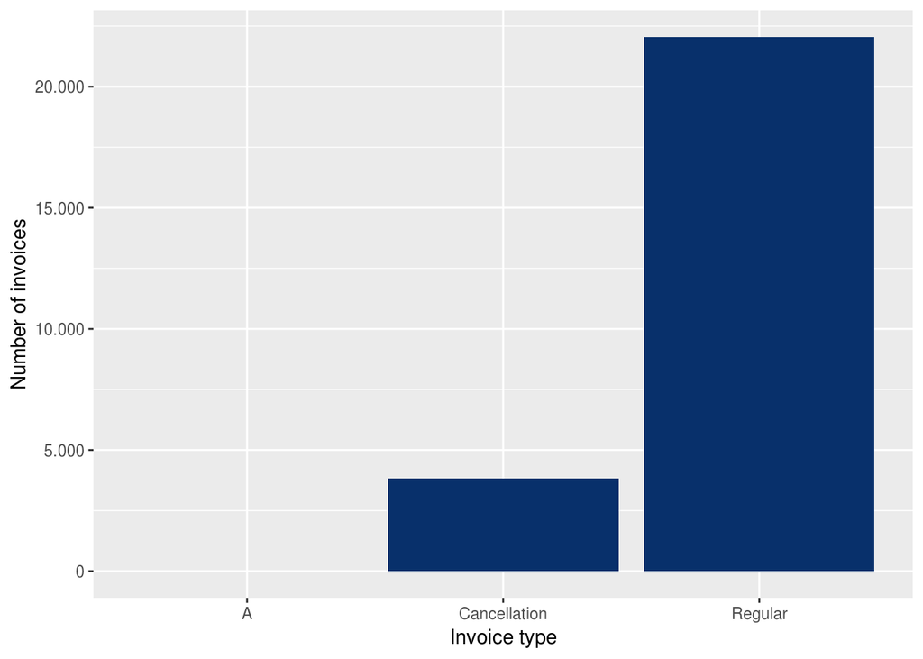

```r
# calculate summary stats in Spark and pull the result into R
cancel_summary <- invoices_tbl %>%
  group_by(InvoicePrefix) %>%
  summarise(invoices = n(),
            amounts = sum(InvoiceAmount, na.rm = TRUE)) %>%
  mutate(InvoiceType = ifelse(is.na(InvoicePrefix), "Regular", ifelse(InvoicePrefix == "C", "Cancellation", InvoicePrefix))) %>%
  collect()

# use ggplot2 for data display - number of invoices by invoice type
ggplot(cancel_summary) +
  geom_bar(aes(x = InvoiceType, y = invoices), stat = "identity", position = "dodge", fill = "#08306b") +
  scale_y_continuous(labels = scales::format_format(big.mark = ".", decimal.mark = ",", scientific = FALSE)) +
  labs(x = "Invoice type", y = "Number of invoices")
```

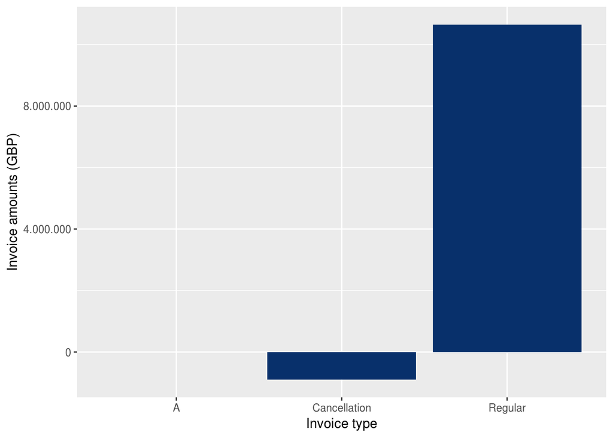

```r
# invoice amounts by invoice type
ggplot(cancel_summary) +
  geom_bar(aes(x = InvoiceType, y = amounts), stat = "identity", position = "dodge", fill = "#08306b") +
  scale_y_continuous(labels = scales::format_format(big.mark = ".", decimal.mark = ",", scientific = FALSE)) +
  labs(x = "Invoice type", y = "Invoice amounts (GBP)")
```

How do cancellations relate to invoices? Is there a cancellation for every invoice? Is there a relationship? In order to realistically evaluate the sales performance, it would be ideal if I could remove cancellations and their corresponding invoices - as they do not relate to revenue. Let’s look at top 10 cancellations by amount:

```r
invoices_tbl %>%
  filter(InvoicePrefix == "C") %>%
  arrange(desc(InvoiceAmount)) %>%
  filter(rank(InvoiceAmount) <= 10)
```

| InvoiceNo <chr> | InvoiceStatus <chr> | CustomerID <dbl> | Country <chr> | InvoiceDate <S3: POSIXct> | LineItems <dbl> | ItemQuantity <dbl> |  |
| --- | --- | --- | --- | --- | --- | --- | --- |
| C581484 | NA | 16446 | United Kingdom | 2011-12-09 09:27:00 | 1 | -80995 |  |
| C541433 | NA | 12346 | United Kingdom | 2011-01-18 10:17:00 | 1 | -74215 |  |
| C556445 | NA | 15098 | United Kingdom | 2011-06-10 15:31:00 | 1 | -1 |  |
| C550456 | NA | 15749 | United Kingdom | 2011-04-18 13:08:00 | 5 | -9014 |  |
| C580605 | NA | NaN | United Kingdom | 2011-12-05 11:36:00 | 1 | -1 |  |
| C540117 | NA | NaN | United Kingdom | 2011-01-05 09:55:00 | 1 | -1 |  |
| C540118 | NA | NaN | United Kingdom | 2011-01-05 09:57:00 | 1 | -1 |  |
| C537630 | NA | NaN | United Kingdom | 2010-12-07 15:04:00 | 1 | -1 |  |
| C537651 | NA | NaN | United Kingdom | 2010-12-07 15:49:00 | 1 | -1 |  |
| C537644 | NA | NaN | United Kingdom | 2010-12-07 15:34:00 | 1 | -1 |  |

1-10 of 10 rows | 1-7 of 9 columns

All cancellations have a C prefix - is it possible that cancellation relates to invoice by number? Let’s test that.

Let’s try joining the cancellations to invoices by number without the prefix.

```r
invoices_tbl %>%
  filter(InvoicePrefix == "C") %>%
  select(InvoiceNo, InvoiceDate, InvoiceAmount) %>%
  transmute(CancelNo = InvoiceNo,
            CancelDate = InvoiceDate,
            CancelAmount = InvoiceAmount,
            InvoiceNo = substr(InvoiceNo, 2, 7)) %>%
  left_join(invoices_tbl, by = "InvoiceNo") %>%
  select(CancelNo, CancelDate, CancelAmount, InvoiceNo, InvoiceDate, InvoiceAmount) %>%
  arrange(CancelAmount) %>%
  filter(!is.na(InvoiceAmount))
```

| CancelNo <chr> | CancelDate <dbl> | CancelAmount <dbl> | InvoiceNo <chr> | InvoiceDate <dbl> | InvoiceAmount <dbl> |
| --- | --- | --- | --- | --- | --- |

0 rows

No matches. So there is no meaningful relationship between cancellations and regular invoices.

Let’s try to find a couple of invoices and their cancellations by the exact amount.

```r
invoices_tbl %>%
  filter(abs(InvoiceAmount) %in% c(168469.60, 77183.60, 38970.00, 22998.40, 17836.46, 16888.02, 16453.71)) %>%
  arrange(desc(abs(InvoiceAmount)))
```

| InvoiceNo <chr> | InvoiceStatus <chr> | CustomerID <dbl> | Country <chr> | InvoiceDate <S3: POSIXct> | LineItems <dbl> | ItemQuantity <dbl> |  |
| --- | --- | --- | --- | --- | --- | --- | --- |
| 581483 | Cancelled | 16446 | United Kingdom | 2011-12-09 09:15:00 | 1 | 80995 |  |
| C581484 | NA | 16446 | United Kingdom | 2011-12-09 09:27:00 | 1 | -80995 |  |
| C541433 | NA | 12346 | United Kingdom | 2011-01-18 10:17:00 | 1 | -74215 |  |
| 541431 | Cancelled | 12346 | United Kingdom | 2011-01-18 10:01:00 | 1 | 74215 |  |
| C556445 | NA | 15098 | United Kingdom | 2011-06-10 15:31:00 | 1 | -1 |  |
| 556444 | Cancelled | 15098 | United Kingdom | 2011-06-10 15:28:00 | 1 | 60 |  |
| C550456 | NA | 15749 | United Kingdom | 2011-04-18 13:08:00 | 5 | -9014 |  |
| C580605 | NA | NaN | United Kingdom | 2011-12-05 11:36:00 | 1 | -1 |  |
| C540117 | NA | NaN | United Kingdom | 2011-01-05 09:55:00 | 1 | -1 |  |
| C540118 | NA | NaN | United Kingdom | 2011-01-05 09:57:00 | 1 | -1 |  |

1-10 of 10 rows | 1-7 of 9 columns

A-ha! So there is a kind of relationship - at least for 3 largest invoices. Still, those invoices make up cca 30% of total cancellation value. I’ll mark those as cancelled at the start of the analysis, and exclude them from all sales analyses.

Now that we have marked cancelled invoices, let’s continue the analysis only on regular, non-cancelled invoices.

```r
invoices_tbl <- invoices_tbl %>%
  filter(is.na(InvoicePrefix) & is.na(InvoiceStatus))
```

Let’s now return to an earlier question - do invoices without CustomerID mean retail customers? Let’s compare the distributions of number of line items for those two groups. If no-CustomerID group tends to have fewer line items than with-CustomerID group, it could be retail customers.

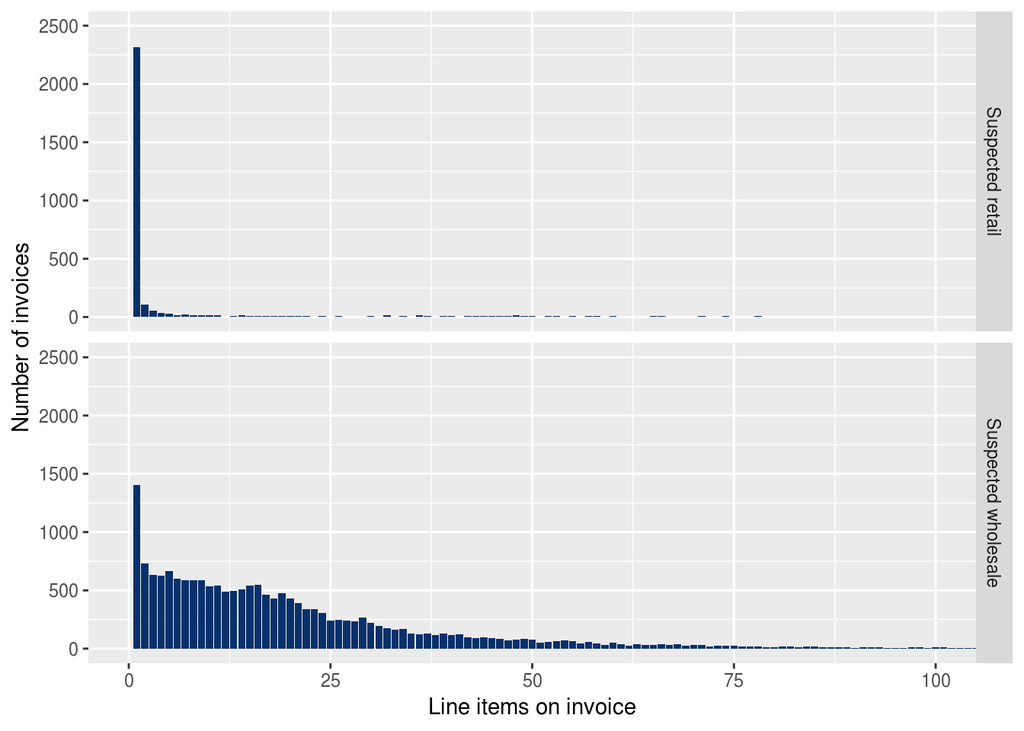

```r
invoices_tbl %>%
  mutate(SuspCustGroup = ifelse(is.na(CustomerID), "Suspected retail", "Suspected wholesale")) %>%
  group_by(LineItems, SuspCustGroup) %>%
  summarise(num_invoices = n(), invoice_amounts = sum(InvoiceAmount, na.rm = TRUE)) %>%
  collect() %>%
  ggplot() +
  geom_bar(aes(x = LineItems, y = num_invoices), stat = "identity", fill = "#08306b") +
    coord_cartesian(xlim = c(0, 100), ylim = c(0, 2500)) +
    labs(x = "Line items on invoice",
         y = "Number of invoices",
         fill = "Customer group") +
    scale_fill_brewer(palette = "Set1") +
  facet_grid(SuspCustGroup ~ .)
```

YES - the data confirms my assumption! In the suspected retail group there are a LOT more invoices with low number of items, while the suspected wholesalers group makes orders with a larger number of items. I’ll introduce Retail and Wholesale groups to the rest of the data analysis. In a real-world project, this assumption would be double-checked with client businesspeople.

```r
invoices_tbl <- invoices_tbl %>%
  mutate(CustomerGroup = ifelse(is.na(CustomerID), "Retail", "Wholesale"))
```

Let’s now look at total number of invoices and revenue split by customer group:

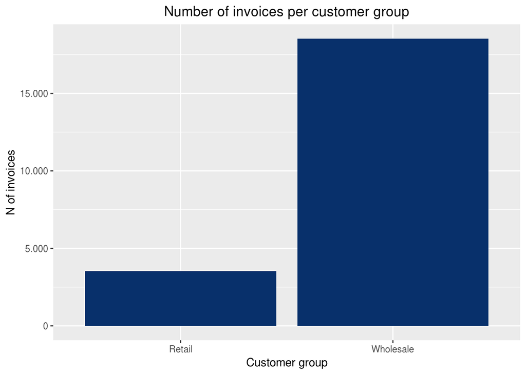

```r
cust_group_stats <- invoices_tbl %>%
  group_by(CustomerGroup) %>%
  summarise(n_invoices = n(),
            invoice_amount = sum(InvoiceAmount, na.rm = TRUE)) %>%
  collect()

ggplot(cust_group_stats) +
  geom_bar(aes(x = CustomerGroup, y = n_invoices), stat = "identity", fill = "#08306b") +
  scale_y_continuous(labels = scales::format_format(big.mark = ".", decimal.mark = ",", scientific = FALSE)) +
  labs(x = "Customer group",
       y = "N of invoices",
       title = "Number of invoices per customer group") +
  theme(plot.title = element_text(hjust = 0.5))
```

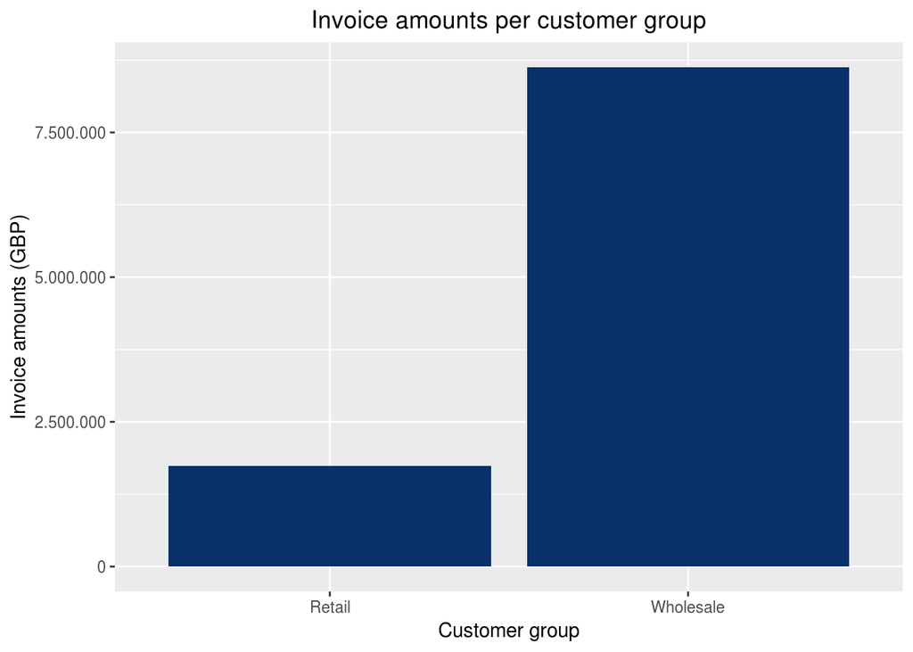

```r
ggplot(cust_group_stats) +
  geom_bar(aes(x = CustomerGroup, y = invoice_amount), stat = "identity", fill = "#08306b") +
  scale_y_continuous(labels = scales::format_format(big.mark = ".", decimal.mark = ",", scientific = FALSE)) +
  labs(x = "Customer group",
       y = "Invoice amounts (GBP)",
       title = "Invoice amounts per customer group") +
  theme(plot.title = element_text(hjust = 0.5))
```

A new insight - retail part of the business is quite small, roughly 1/6 of the total business (invoices issued AND revenue). This means that business optimization should be focused on the wholesale side of the business to maximize impact on revenue. In a real-life project, this decision would be discussed with the businesspeople.

Let’s look at total sales in a year, per month and customer group:

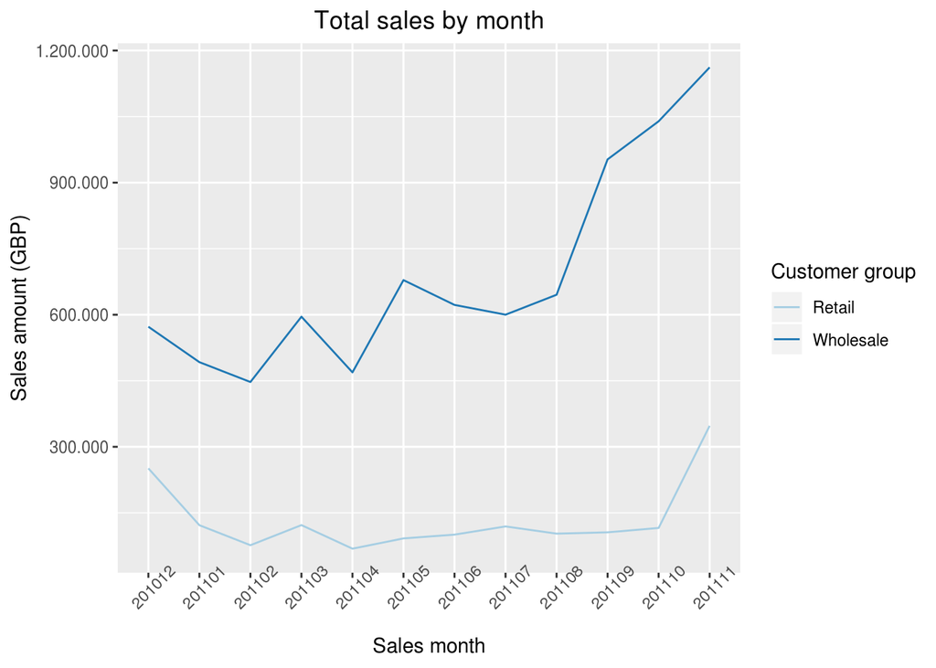

```r
# removing month 201112 because the data is not complete for that month (only up to 9/12/2011)
invoices_tbl %>%
  mutate(SalesMonth = as.character(as.integer(year(InvoiceDate) * 100 + month(InvoiceDate)))) %>%
  group_by(CustomerGroup, SalesMonth) %>%
  summarise(SalesAmount = sum(InvoiceAmount, na.rm = TRUE)) %>%
  filter(!is.na(SalesMonth) & SalesMonth != 201112) %>%
  collect %>%
  ggplot() +
    geom_line(aes(x = SalesMonth, y = SalesAmount, group = CustomerGroup, color = CustomerGroup)) +
    labs(x = "Sales month",
         y = "Sales amount (GBP)",
         title = "Total sales by month",
         color = "Customer group") +
    theme(axis.text.x = element_text(angle = 45),plot.title = element_text(hjust = 0.5)) +
    scale_y_continuous(labels = scales::format_format(big.mark = ".", decimal.mark = ",", scientific = FALSE)) +
    scale_color_brewer(palette = "Paired")
```

For wholesalers, peak months are those leading to season changes - March (start of spring), May (summer is coming), September (autumn is coming) and of course Christmas and New Year. This is not surprising, as the company sells all-occasion gifts - they change with the seasons of the year. Sales uptick comes prior to season change, as wholesale customers are stocking with the coming season merchandise. There is also significant sales growth visible towards the end of the year, not caused by seasonality only - sales in November 2011 is twice the amount from December 2010. It will be interesting to see whether there are some particular items or customers driving that growth.

For retail customers, seasonality is visible mainly in November and December (shopping season leading up to Christmas).

Let’s look at contribution of countries - maybe clients from new countries are driving the wholesale growth?

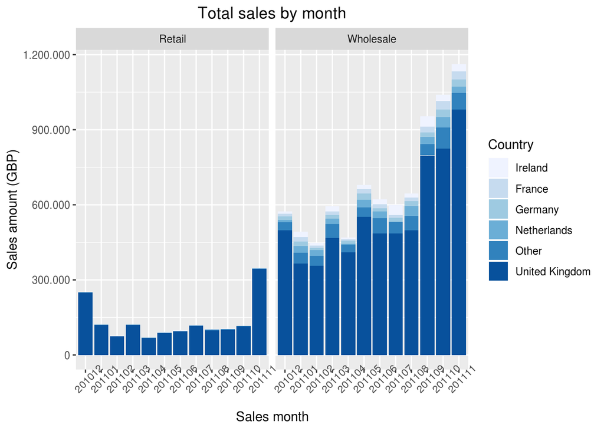

```r
top_5_sales_countries <- invoices_tbl %>%
  group_by(Country) %>%
  summarise(Amount = sum(InvoiceAmount, na.rm = TRUE)) %>%
  filter(rank(desc(Amount)) <= 5) %>%
  collect

invoices_tbl %>%
  mutate(SalesMonth = as.character(as.integer(year(InvoiceDate) * 100 + month(InvoiceDate))),
         Country = ifelse(Country %in% top_5_sales_countries$Country, Country, "Other")) %>%
  group_by(CustomerGroup, SalesMonth, Country) %>%
  summarise(SalesAmount = sum(InvoiceAmount, na.rm = TRUE)) %>%
  filter(!is.na(SalesMonth) & SalesMonth != 201112) %>%
  collect %>%
  ggplot() +
    geom_bar(aes(x = SalesMonth, y = SalesAmount, fill = reorder(factor(Country), SalesAmount)), stat = "identity") +
    labs(x = "Sales month",
         y = "Sales amount (GBP)",
         title = "Total sales by month",
         fill = "Country") +
    theme(axis.text.x = element_text(angle = 45), plot.title = element_text(hjust = 0.5)) +
    scale_y_continuous(labels = scales::format_format(big.mark = ".", decimal.mark = ",", scientific = FALSE)) +
    scale_fill_brewer(palette = "Blues") +
    facet_grid(. ~ CustomerGroup)
```

For exploratory purposes, I’ll overlay the sales data by country on a world map. That will give a clearer impression on the reach of the shop. I’ll create a choropleth map using the leaflet package.

```r
library(leaflet)
library(rworldmap)

# aggregate revenue by country
sales_by_country <- invoices_tbl %>%
  group_by(Country) %>%
  summarise(Amount = sum(InvoiceAmount, na.rm = TRUE)) %>%
  collect

  # join the revenue by country to the world map of countries
  sPDF <- joinCountryData2Map(sales_by_country
                                ,joinCode = "NAME"
                                ,nameJoinColumn = "Country", verbose = FALSE)
```

```
## 34 codes from your data successfully matched countries in the map
## 4 codes from your data failed to match with a country code in the map
## 209 codes from the map weren't represented in your data
```

```r
    # select only the countries which generated revenue
    existing_countries <- subset(sPDF, !is.na(Amount))

    # create spending classes for revenues per country
    bins <- c(0, 50000, 100000, 150000, 200000, 250000, 300000, Inf)
    # assign a color to each of the classes
    pal <- colorBin("YlOrRd", domain = existing_countries$Amount, bins = bins)

    # create labels with actual revenue amounts per country, for hover info
    labels <- paste0("<strong>", existing_countries$Country, "</strong><br/>",
                     format(existing_countries$Amount, digits = 0, big.mark = ".", decimal.mark = ",", scientific = FALSE),
                     " GBP") %>% lapply(htmltools::HTML)

    # create the cloropleth map
    leaflet(existing_countries) %>%
      addTiles() %>%  # Add default OpenStreetMap map tiles
      addPolygons(
        fillColor = ~pal(Amount),
        weight = 1,
        opacity = 1,
        color = "white",
        dashArray = "3",
        fillOpacity = 0.7,
        highlight = highlightOptions(
          weight = 2,
          color = "#666",
          dashArray = "",
          fillOpacity = 0.7,
          bringToFront = TRUE),
        label = labels,
        labelOptions = labelOptions(
          style = list("font-weight" = "normal", padding = "3px 8px"),
          textsize = "15px",
          direction = "auto")) %>%
      addLegend(pal = pal, values = ~Amount, opacity = 0.7, title = NULL,
                                            position = "topright") %>%
      setView(17,34,2)
```

[interactive chart not shown]

Besides the neighboring countries, there is one other country with a marginally significant revenue - Australia!

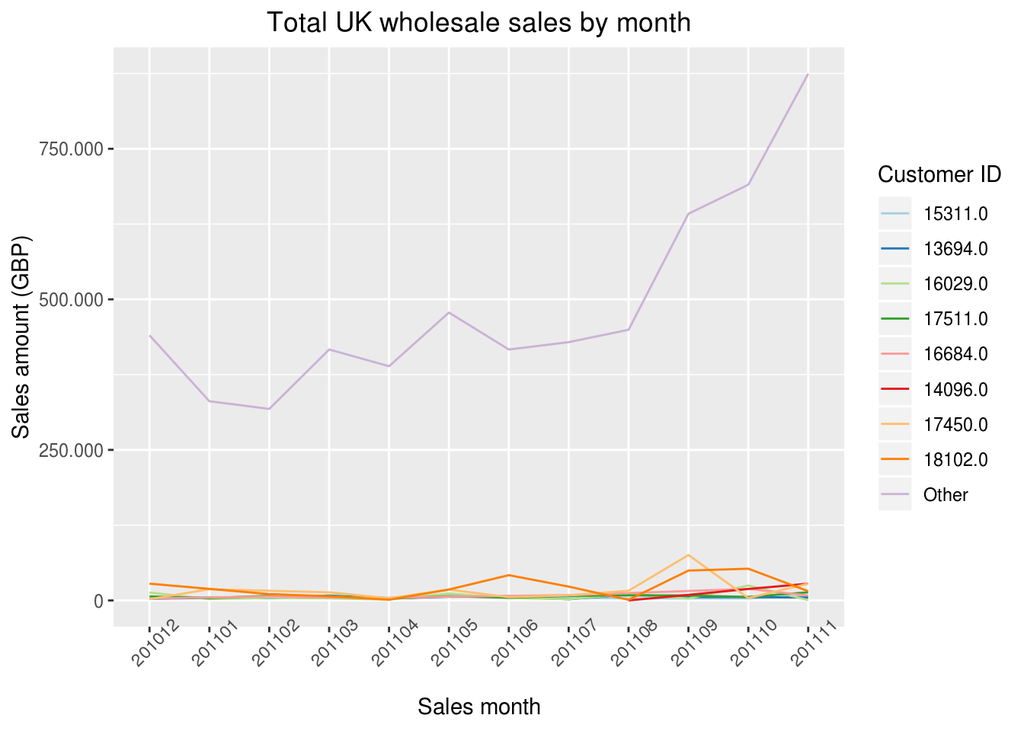

```r
top_UK_sales_customers <- invoices_tbl %>%
  filter(CustomerGroup == "Wholesale" & Country == "United Kingdom") %>%
  group_by(CustomerID) %>%
  summarise(Amount = sum(InvoiceAmount, na.rm = TRUE)) %>%
  filter(rank(desc(Amount)) <= 8) %>%
  collect

invoices_tbl %>%
  filter(CustomerGroup == "Wholesale" & Country == "United Kingdom") %>%
  mutate(SalesMonth = as.character(as.integer(year(InvoiceDate) * 100 + month(InvoiceDate))),
         CustomerID = ifelse(CustomerID %in% top_UK_sales_customers$CustomerID, CustomerID, "Other")) %>%
  group_by(CustomerGroup, SalesMonth, CustomerID) %>%
  summarise(SalesAmount = sum(InvoiceAmount, na.rm = TRUE)) %>%
  filter(!is.na(SalesMonth) & SalesMonth != 201112) %>%
  collect %>%
  ggplot() +
    geom_line(aes(x = SalesMonth, y = SalesAmount, group = reorder(factor(CustomerID), SalesAmount), color = reorder(factor(CustomerID), SalesAmount)), stat = "identity") +
    labs(x = "Sales month",
         y = "Sales amount (GBP)",
         title = "Total UK wholesale sales by month",
         color = "Customer ID") +
    theme(axis.text.x = element_text(angle = 45), plot.title = element_text(hjust = 0.5)) +
    scale_y_continuous(labels = scales::format_format(big.mark = ".", decimal.mark = ",", scientific = FALSE)) +
    scale_color_brewer(palette = "Paired")
```

Customers 17450 and 18102 have had some increased spending in September and October 2011, but those do not explain the sales growth.

Let’s try identifying top spenders from September - November period (they do not necessarily correspond to overall top spenders).

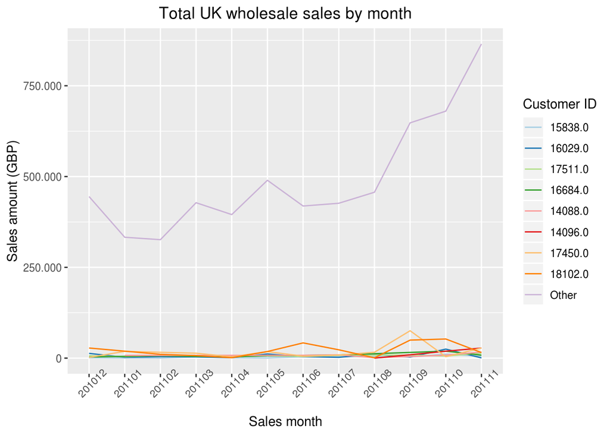

```r
top_UK_sep_nov_customers <- invoices_tbl %>%
  mutate(SalesMonth = as.character(as.integer(year(InvoiceDate) * 100 + month(InvoiceDate)))) %>%
  filter(CustomerGroup == "Wholesale" & Country == "United Kingdom" & SalesMonth >= 201109 & SalesMonth < 201112) %>%
  group_by(CustomerID) %>%
  summarise(Amount = sum(InvoiceAmount, na.rm = TRUE)) %>%
  filter(rank(desc(Amount)) <= 8) %>%
  collect

invoices_tbl %>%
  filter(CustomerGroup == "Wholesale" & Country == "United Kingdom") %>%
  mutate(SalesMonth = as.character(as.integer(year(InvoiceDate) * 100 + month(InvoiceDate))),
         CustomerID = ifelse(CustomerID %in% top_UK_sep_nov_customers$CustomerID, CustomerID, "Other")) %>%
  group_by(CustomerGroup, SalesMonth, CustomerID) %>%
  summarise(SalesAmount = sum(InvoiceAmount, na.rm = TRUE)) %>%
  filter(!is.na(SalesMonth) & SalesMonth != 201112) %>%
  collect %>%
  ggplot() +
    geom_line(aes(x = SalesMonth, y = SalesAmount, group = reorder(factor(CustomerID), SalesAmount), color = reorder(factor(CustomerID), SalesAmount)), stat = "identity") +
    labs(x = "Sales month",
         y = "Sales amount (GBP)",
         title = "Total UK wholesale sales by month",
         color = "Customer ID") +
    theme(axis.text.x = element_text(angle = 45), plot.title = element_text(hjust = 0.5)) +
    scale_y_continuous(labels = scales::format_format(big.mark = ".", decimal.mark = ",", scientific = FALSE)) +
    scale_color_brewer(palette = "Paired")
```

So the UK wholesale growth is obviously not coming from top spenders. Is it coming due to increased number of customers (new customers)?

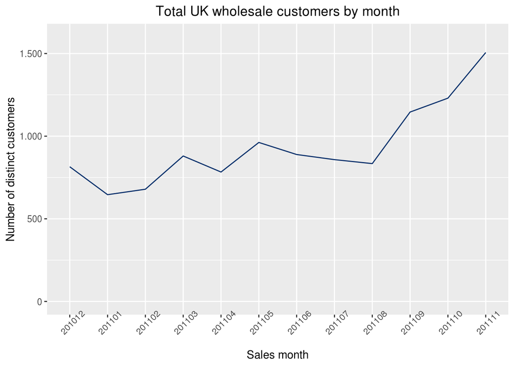

```r
invoices_tbl %>%
  filter(CustomerGroup == "Wholesale" & Country == "United Kingdom") %>%
  mutate(SalesMonth = as.character(as.integer(year(InvoiceDate) * 100 + month(InvoiceDate)))) %>%
  group_by(SalesMonth) %>%
  summarise(NumberDistinctCustomers = n_distinct(CustomerID)) %>%
  filter(!is.na(SalesMonth) & SalesMonth != 201112) %>%
  collect %>%
  ggplot() +
    geom_line(aes(x = SalesMonth, y = NumberDistinctCustomers, group = "dummy"), colour = "#08306b") +
    labs(x = "Sales month",
         y = "Number of distinct customers",
         title = "Total UK wholesale customers by month") +
    theme(axis.text.x = element_text(angle = 45), plot.title = element_text(hjust = 0.5)) +
    scale_y_continuous(labels = scales::format_format(big.mark = ".", decimal.mark = ",", scientific = FALSE)) +
    coord_cartesian(ylim = c(0, 1600))
```

So, the sales growth seems to be coming from new customers. Let’s divide the customers into new (didn’t have purchases before September 2011) and existing customers (had purchases before September 2011). Then we’ll be able to see the influence of new customers on sales growth.

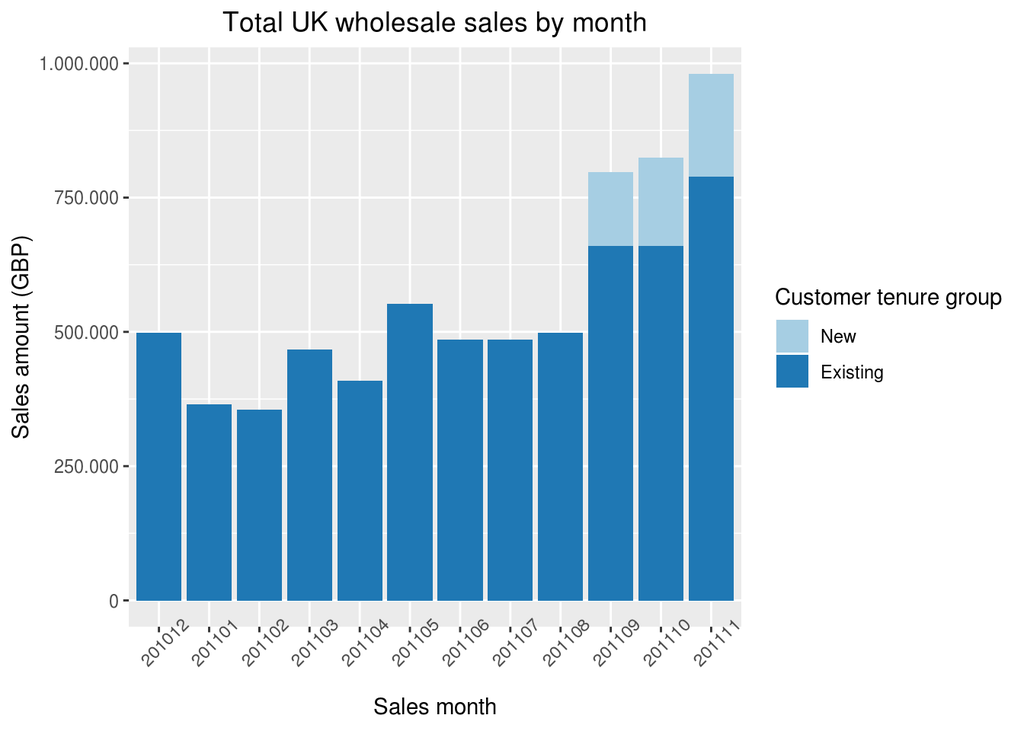

```r
customer_tenure_tbl <- invoices_tbl %>%
  mutate(SalesMonth = as.character(as.integer(year(InvoiceDate) * 100 + month(InvoiceDate)))) %>%
  filter(!is.na(SalesMonth) & CustomerGroup == "Wholesale" & Country == "United Kingdom") %>%
  group_by(CustomerID) %>%
  summarise(FirstPurchase = min(SalesMonth, na.rm = TRUE)) %>%
  mutate(TenureGroup = ifelse(FirstPurchase < 201109, "Existing", "New"))

invoices_tbl %>%
  mutate(SalesMonth = as.character(as.integer(year(InvoiceDate) * 100 + month(InvoiceDate)))) %>%
  filter(!is.na(SalesMonth) & SalesMonth != 201112 & CustomerGroup == "Wholesale" & Country == "United Kingdom") %>%
  left_join(customer_tenure_tbl, by = "CustomerID") %>%
  group_by(TenureGroup, SalesMonth) %>%
  summarise(SalesAmount = sum(InvoiceAmount, na.rm = TRUE)) %>%
  collect %>%
  ggplot() +
    geom_bar(aes(x = SalesMonth, y = SalesAmount, fill = reorder(factor(TenureGroup), SalesAmount)), stat = "identity") +
    labs(x = "Sales month",
         y = "Sales amount (GBP)",
         title = "Total UK wholesale sales by month",
         fill = "Customer tenure group") +
    theme(axis.text.x = element_text(angle = 45), plot.title = element_text(hjust = 0.5)) +
    scale_y_continuous(labels = scales::format_format(big.mark = ".", decimal.mark = ",", scientific = FALSE)) +
    scale_fill_brewer(palette = "Paired")
```

So, roughly half of the growth comes from new customers, and half from existing. Let’s make this a more actionable insight - I’ll produce a list of top 10 new customer spenders - so that the sales department can prioritize them in the sales process:

```r
invoices_tbl %>%
  mutate(SalesMonth = as.character(as.integer(year(InvoiceDate) * 100 + month(InvoiceDate)))) %>%
  filter(!is.na(SalesMonth) & CustomerGroup == "Wholesale" & Country == "United Kingdom") %>%
  left_join(customer_tenure_tbl, by = "CustomerID") %>%
  filter(TenureGroup == "New") %>%
  group_by(CustomerID, FirstPurchase) %>%
  summarise(SalesAmount = sum(InvoiceAmount, na.rm = TRUE)) %>%
  ungroup() %>%
  filter(rank(desc(SalesAmount)) <= 10) %>%
  arrange(desc(SalesAmount)) %>%
  collect()
```

| CustomerID <dbl> | FirstPurchase <chr> | SalesAmount <dbl> |  |  |
| --- | --- | --- | --- | --- |
| 16000 | 201112 | 12393.70 |  |  |
| 18139 | 201111 | 8438.34 |  |  |
| 17509 | 201110 | 6115.14 |  |  |
| 18251 | 201109 | 4314.72 |  |  |
| 14547 | 201110 | 4007.54 |  |  |
| 15195 | 201112 | 3861.00 |  |  |
| 16240 | 201109 | 3718.80 |  |  |
| 17528 | 201109 | 3628.50 |  |  |
| 15113 | 201110 | 3609.33 |  |  |
| 15484 | 201109 | 3594.31 |  |  |

1-10 of 10 rows

How many times in a year do wholesale customers make purchases? How many of them are frequent repeat customers?

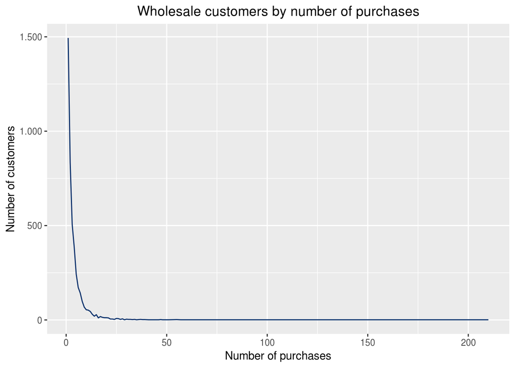

```r
invoices_tbl %>%
  filter(CustomerGroup == "Wholesale") %>%
  group_by(CustomerID) %>%
  summarise(NumInvoices = n()) %>%
  ungroup() %>%
  group_by(NumInvoices) %>%
  summarise(NumCustomers = n()) %>%
  arrange(NumInvoices) %>%
  collect() %>%
  ggplot() +
  geom_freqpoly(aes(x = NumInvoices, y = NumCustomers), stat = "identity", colour = "#08306b") +
  labs(x = "Number of purchases",
       y = "Number of customers",
       title = "Wholesale customers by number of purchases") +
  scale_y_continuous(labels = scales::format_format(big.mark = ".", decimal.mark = ",", scientific = FALSE)) +
  theme(plot.title = element_text(hjust = 0.5))
```

A typical lognormal distribution - a few customers which are very frequent buyers, and a lot of single time buyers. It would be easier to see it displayed a bit differently:

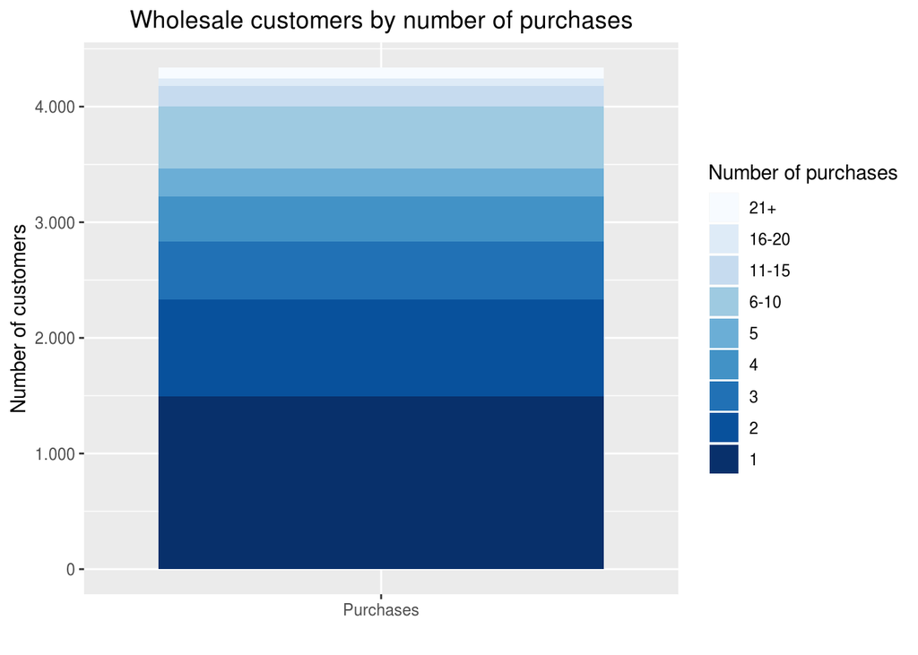

```r
invoices_tbl %>%
  filter(CustomerGroup == "Wholesale") %>%
  group_by(CustomerID) %>%
  summarise(NumInvoices = as.double(n())) %>%
  ungroup() %>%
  ft_bucketizer(input_col = "NumInvoices", output_col = "NumInvoicesDisc", splits = c(1,2,3,4,5,6,11,16,21,Inf)) %>%
  group_by(NumInvoicesDisc) %>%
  summarise(NumCustomers = n()) %>%
  arrange(NumInvoicesDisc) %>%
  collect() %>%
  mutate(NumInvoicesDisc = ordered(NumInvoicesDisc,
                                   levels = c(0,1,2,3,4,5,6,7,8),
                                   labels = c("1","2","3","4","5","6-10","11-15","16-20","21+")),
         Group = "Purchases") %>%
  ggplot() +
  geom_bar(aes(x = Group, fill = reorder(NumInvoicesDisc, desc(NumInvoicesDisc)), y = NumCustomers), stat = "identity", position = "stack") +
  labs(x = "",
       y = "Number of customers",
       title = "Wholesale customers by number of purchases",
       fill = "Number of purchases") +
  scale_y_continuous(labels = scales::format_format(big.mark = ".", decimal.mark = ",", scientific = FALSE)) +
  theme(plot.title = element_text(hjust = 0.5)) +
  scale_fill_brewer(palette = "Blues")
```

30% of the wholesale customers are one-time buyers (only one purchase in a year). Another 20% are two-time buyers, and another 10% had 3 purchases in a year. This would be a good time to discuss with the client businesspeople the concept of regular customers. How many purchases in a year make a regular customer? Since the store is offering all-occasion gifts, and they tend to change with the seasons (causing upsurges in sales), I’ll assume regular customers should have at least 4 purchases in a year - one for each season. Let’s see the top 10 spending regular customers - those should be handled with special attention.

```r
invoices_tbl %>%
  filter(CustomerGroup == "Wholesale") %>%
  group_by(CustomerID) %>%
  summarise(NumInvoices = n(),
            AmountSpent = sum(InvoiceAmount, na.rm = TRUE),
            FirstPurchase = min(InvoiceDate, na.rm = TRUE),
            AvgPurchaseValue = sum(InvoiceAmount, na.rm = TRUE) / n()) %>%
  ungroup() %>%
  filter(NumInvoices >= 4 & rank(desc(AmountSpent)) <= 10)
```

| CustomerID <dbl> | NumInvoices <dbl> | AmountSpent <dbl> | FirstPurchase <S3: POSIXct> | AvgPurchaseValue <dbl> |
| --- | --- | --- | --- | --- |
| 14646 | 74 | 280206.02 | 2010-12-20 10:09:00 | 3786.5678 |
| 18102 | 60 | 259657.30 | 2010-12-07 16:42:00 | 4327.6217 |
| 17450 | 46 | 194550.79 | 2010-12-07 09:23:00 | 4229.3650 |
| 14911 | 201 | 143825.06 | 2010-12-01 14:05:00 | 715.5476 |
| 12415 | 21 | 124914.53 | 2011-01-06 11:12:00 | 5948.3110 |
| 14156 | 55 | 117379.63 | 2010-12-03 11:48:00 | 2134.1751 |
| 17511 | 31 | 91062.38 | 2010-12-01 10:19:00 | 2937.4961 |
| 16029 | 63 | 81024.84 | 2010-12-01 09:57:00 | 1286.1086 |
| 16684 | 28 | 66653.56 | 2010-12-16 17:34:00 | 2380.4843 |
| 14096 | 17 | 65164.79 | 2011-08-30 10:49:00 | 3833.2229 |

1-10 of 10 rows

To wrap up this part of analysis, I’ll create and store a wholesale customers table with some descriptive features. It will come in handy later - i.e. for customer behaviour segmentation. I’ll add the following customer features:

[output not shown]

```r
if(!file.exists("Data/spark-warehouse/wholesale_customers")){
  wholesale_customers_tbl <- invoices_tbl %>%
    filter(CustomerGroup == "Wholesale") %>%
    select(CustomerID, Country, InvoiceNo, InvoiceDate, InvoiceAmount) %>%
    arrange(CustomerID, InvoiceDate) %>%
    group_by(CustomerID) %>%
    mutate(PreviousPurchase = lag(InvoiceDate, 1),
           DaysSincePrevPurchase = ifelse(!is.na(lag(InvoiceDate, 1)), datediff(date(InvoiceDate), date(lag(InvoiceDate, 1))), NA)) %>%
    summarise(Country = max(Country, na.rm = TRUE),
              NumPurchases = n(),
              FirstPurchase = min(InvoiceDate, na.rm = TRUE),
              LastPurchase = max(InvoiceDate, na.rm = TRUE),
              AmountSpent = sum(InvoiceAmount, na.rm = TRUE),
              AvgPurchaseValue = mean(InvoiceAmount, na.rm = TRUE),
              StddevPurchaseValue = sd(InvoiceAmount),
              MinPurchaseValue = min(InvoiceAmount, na.rm = TRUE),
              MaxPurchaseValue = min(InvoiceAmount, na.rm = TRUE),
              AvgDaysBetweenPurchases = mean(DaysSincePrevPurchase, na.rm = TRUE),
              StddevDaysBetweenPurchases = sd(DaysSincePrevPurchase),
              MinDaysBetweenPurchases = min(DaysSincePrevPurchase, na.rm = TRUE),
              MaxDaysBetweenPurchases = max(DaysSincePrevPurchase, na.rm = TRUE),
              DaysSinceLastPurchase = datediff(to_date("2011-12-10 00:00:00"), date(max(InvoiceDate, na.rm = TRUE))),
              TenureDays = datediff(to_date("2011-12-10 00:00:00"), date(min(InvoiceDate, na.rm = TRUE))),
              SeasonalNumPurchases = sum(ifelse(month(InvoiceDate) %in% c(3,5,9,11,12), 1, 0), na.rm = TRUE),
              SeasonalAmountSpent = sum(ifelse(month(InvoiceDate) %in% c(3,5,9,11,12), InvoiceAmount, 0), na.rm = TRUE)) %>%
    ungroup() %>%
    mutate(TenureGroup = ifelse(TenureDays > 90, "Existing", "New"))

    # register the temp table in Spark
    sdf_register(wholesale_customers_tbl, "wholesale_customers")

    # save the Spark DataFrame to a Parquet file(s) for persistence across sessions (Spark applications) - to a local filesystem, current project Data/spark-warehouse subdirectory
    spark_write_parquet(wholesale_customers_tbl,str_c("file:", getwd(), "/Data/spark-warehouse/wholesale_customers"), mode = "overwrite")
}
```

Just a quick check if the customer records are unique:

```r
wholesale_customers_tbl <- spark_read_parquet(sc, "wholesale_customers", str_c("file:", getwd(), "/Data/spark-warehouse/wholesale_customers"), mode = "overwrite")
# check if the customer records are unique
wholesale_customers_tbl %>%
  summarise(n_rows = n(),
            n_distinct_customers = n_distinct(CustomerID))
```

| n_rows <dbl> | n_distinct_customers <dbl> |  |  |  |
| --- | --- | --- | --- | --- |
| 4338 | 4338 |  |  |  |

1 row

### Product level analysis

I’ll take only regular invoices, as in the invoices analysis.

```r
sales_transactions_tbl <- sales_transactions_tbl %>%
  filter(is.na(InvoicePrefix) & is.na(InvoiceStatus))
```

How many different products are there? From initial data quality I know that some StockCodes have multiple descriptions, so I’ll count over StockCode to avoid duplicates.

```r
sales_transactions_tbl %>%
  summarise(n_dist_products = n_distinct(StockCode))
```

| n_dist_products <dbl> |  |  |  |  |
| --- | --- | --- | --- | --- |
| 4057 |  |  |  |  |

1 row

Let’s now look at those cases with multiple descriptions. I’ll measure the frequency of each multiple case, to see if I can clean it by taking the most frequent descripton for each StockCode.

```r
multiple_descriptions <- sales_transactions_tbl %>%
  group_by(StockCode) %>%
  summarise(n_desc = n_distinct(Description)) %>%
  filter(n_desc > 1)

sales_transactions_tbl %>%
  inner_join(multiple_descriptions, by = "StockCode") %>%
  select(n_desc, StockCode, Description) %>%
  group_by(n_desc, StockCode, Description) %>%
  summarise(n_rows = n()) %>%
  arrange(desc(n_desc), StockCode, desc(n_rows)) %>%
  head(100)
```

| n_desc <dbl> | StockCode <chr> | Description <chr> | n_rows <dbl> |  |
| --- | --- | --- | --- | --- |
| 9 | 20713 | JUMBO BAG OWLS | 667 |  |
| 9 | 20713 | NA | 4 |  |
| 9 | 20713 | found | 1 |  |
| 9 | 20713 | wrongly marked. 23343 in box | 1 |  |
| 9 | 20713 | wrongly marked 23343 | 1 |  |
| 9 | 20713 | wrongly coded-23343 | 1 |  |
| 9 | 20713 | Found | 1 |  |
| 9 | 20713 | Marked as 23343 | 1 |  |
| 9 | 20713 | wrongly coded 23343 | 1 |  |
| 8 | 23084 | RABBIT NIGHT LIGHT | 1036 |  |

Next

123456

...

10

Previous

1-10 of 100 rows

Yes, I can definitely clean up the descriptions by taking the most frequent description for every StockCode. I’ll save the clean product info to a separate table in Spark.

```r
products_tbl <- sales_transactions_tbl %>%
  group_by(StockCode, Description) %>%
  summarise(n_rows = n()) %>%
  filter(rank(desc(n_rows)) == 1) %>%
  select(StockCode, Description)

    # register the temp table in Spark
    sdf_register(products_tbl, "products")
```

| StockCode <chr> | Description <chr> |  |  |  |
| --- | --- | --- | --- | --- |
| 10123G | NA |  |  |  |
| 10135 | COLOURING PENCILS BROWN TUBE |  |  |  |
| 11001 | ASSTD DESIGN RACING CAR PEN |  |  |  |
| 15030 | FAN BLACK FRAME |  |  |  |
| 15044A | PINK PAPER PARASOL |  |  |  |
| 15044D | RED PAPER PARASOL |  |  |  |
| 15056P | EDWARDIAN PARASOL PINK |  |  |  |
| 15056bl | EDWARDIAN PARASOL BLACK |  |  |  |
| 15058A | BLUE POLKADOT GARDEN PARASOL |  |  |  |
| 16014 | SMALL CHINESE STYLE SCISSOR |  |  |  |

Next

123456

...

100

Previous

1-10 of 1,000 rows

```r
    # save the Spark DataFrame to a Parquet file(s) for persistence across sessions (Spark applications) - to a local filesystem, current project Data/spark-warehouse subdirectory
    spark_write_parquet(products_tbl, str_c("file:", getwd(), "/Data/spark-warehouse/products"), mode = "overwrite")
```

I’ll join the clean product names back to transactions to get consistent product descriptions.

```r
sales_transactions_tbl <- sales_transactions_tbl %>%
  select(-Description) %>%
  inner_join(products_tbl, by = "StockCode")
```

How are variations of the same products handled (i.e. same product, different colour)? Let’s look at clean product StockCodes and descriptions, ordered by Stockcode.

```r
products_tbl %>%
  arrange(StockCode) %>%
  head(100)
```

| StockCode <chr> | Description <chr> |  |  |  |
| --- | --- | --- | --- | --- |
| 10002 | INFLATABLE POLITICAL GLOBE |  |  |  |
| 10080 | GROOVY CACTUS INFLATABLE |  |  |  |
| 10120 | DOGGY RUBBER |  |  |  |
| 10123C | HEARTS WRAPPING TAPE |  |  |  |
| 10123G | NA |  |  |  |
| 10124A | SPOTS ON RED BOOKCOVER TAPE |  |  |  |
| 10124G | ARMY CAMO BOOKCOVER TAPE |  |  |  |
| 10125 | MINI FUNKY DESIGN TAPES |  |  |  |
| 10133 | COLOURING PENCILS BROWN TUBE |  |  |  |
| 10134 | NA |  |  |  |

Next

123456

...

10

Previous

1-10 of 100 rows

It seems product variations are handled by product suffixes.

```r
products_tbl %>%
  filter(substr(StockCode, 1, 5) %in% c("15056", "16161")) %>%
  arrange(StockCode)
```

| StockCode <chr> | Description <chr> |  |  |  |
| --- | --- | --- | --- | --- |
| 15056BL | EDWARDIAN PARASOL BLACK |  |  |  |
| 15056N | EDWARDIAN PARASOL NATURAL |  |  |  |
| 15056P | EDWARDIAN PARASOL PINK |  |  |  |
| 15056bl | EDWARDIAN PARASOL BLACK |  |  |  |
| 15056n | EDWARDIAN PARASOL NATURAL |  |  |  |
| 15056p | EDWARDIAN PARASOL PINK |  |  |  |
| 16161G | WRAP BAD HAIR DAY |  |  |  |
| 16161M | WRAP PINK FLOCK |  |  |  |
| 16161P | WRAP ENGLISH ROSE |  |  |  |
| 16161U | WRAP SUKI AND FRIENDS |  |  |  |

1-10 of 10 rows

However, variation naming is not consistent. It would be difficult to extract core product names from variation names.

In addition, not all variations are handled by product suffixes:

```r
products_tbl %>%
  filter(StockCode %in% c("16014", "16015", "16016"))
```

| StockCode <chr> | Description <chr> |  |  |  |
| --- | --- | --- | --- | --- |
| 16014 | SMALL CHINESE STYLE SCISSOR |  |  |  |
| 16015 | MEDIUM CHINESE STYLE SCISSOR |  |  |  |
| 16016 | LARGE CHINESE STYLE SCISSOR |  |  |  |

3 rows

In a real world project, this would be an excellent time to talk to client businesspeople. There most certainly are product groups/taxonomies in the system where this data came from, which would save a lot of work. How many of the total products are actually variations? If there aren’t many, I’ll simply treat them as regular products and go on.

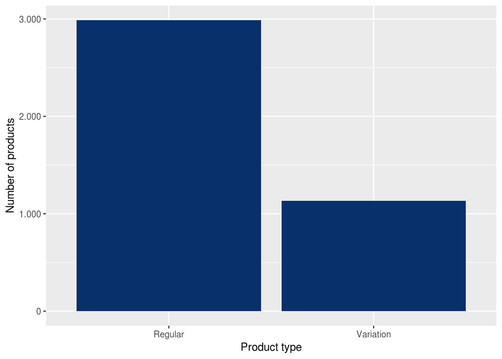

```r
products_tbl %>%
  mutate(ProductType = ifelse(substr(StockCode, -1, 1) %in% letters | substr(StockCode, -1, 1) %in% LETTERS, "Variation", "Regular")) %>%
  group_by(ProductType) %>%
  summarise(n_rows = n()) %>%
  collect %>%
  ggplot() +
  geom_bar(aes(x = ProductType, y = n_rows), stat = "identity", position = "dodge", fill = "#08306b") +
  scale_y_continuous(labels = scales::format_format(big.mark = ".", decimal.mark = ",", scientific = FALSE)) +
  labs(x = "Product type", y = "Number of products")
```

So, roughly a quarter of all products are variations. Is the relationship the same if I look at sales amounts, instead of product counts?

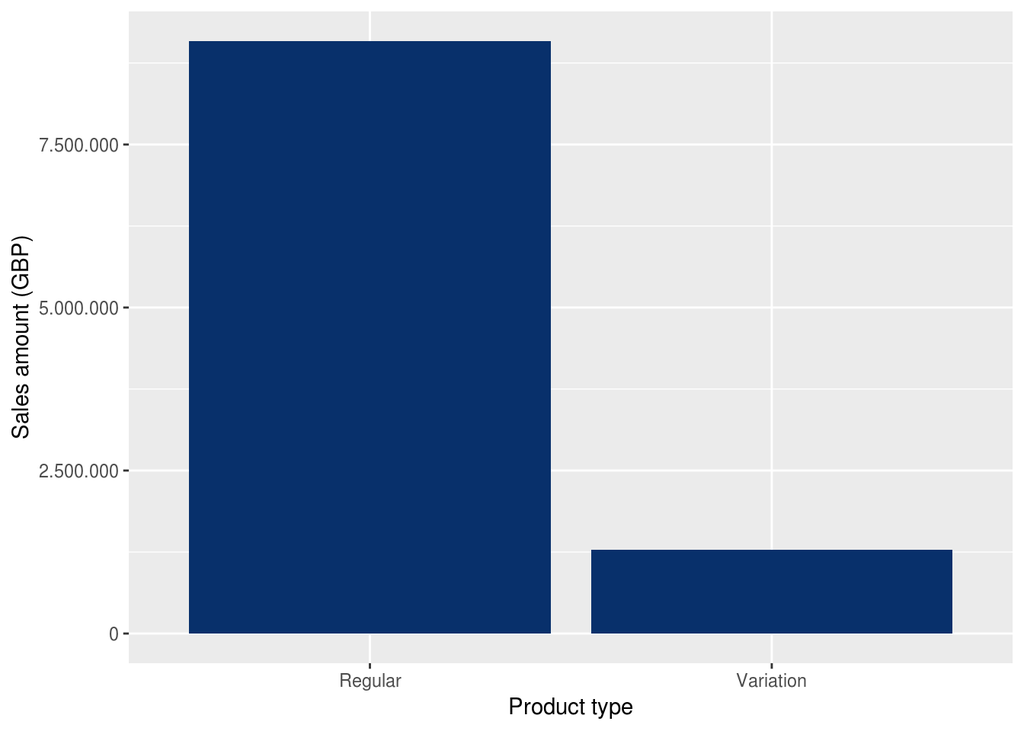

```r
sales_transactions_tbl %>%
  mutate(ProductType = ifelse(substr(StockCode, -1, 1) %in% letters | substr(StockCode, -1, 1) %in% LETTERS, "Variation", "Regular")) %>%
  group_by(ProductType) %>%
  summarise(SalesAmount = sum(Quantity * UnitPrice, na.rm = TRUE)) %>%
  collect %>%
  ggplot() +
  geom_bar(aes(x = ProductType, y = SalesAmount), stat = "identity", position = "dodge", fill = "#08306b") +
  scale_y_continuous(labels = scales::format_format(big.mark = ".", decimal.mark = ",", scientific = FALSE)) +
  labs(x = "Product type", y = "Sales amount (GBP)")
```

Variations take up only 1/7 of the revenue. I can then treat variations as regular products and go on.

What are the top products sold by revenue?

```r
sales_transactions_tbl %>%
  group_by(StockCode, Description) %>%
  summarise(SalesAmount = sum(Quantity * UnitPrice, na.rm = TRUE)) %>%
  filter(rank(desc(SalesAmount)) <= 100) %>%
  arrange(desc(SalesAmount)) %>%
  head(100)
```

| StockCode <chr> | Description <chr> | SalesAmount <dbl> |  |  |
| --- | --- | --- | --- | --- |
| DOT | DOTCOM POSTAGE | 206248.77 |  |  |
| 22423 | REGENCY CAKESTAND 3 TIER | 174484.74 |  |  |
| 85123A | WHITE HANGING HEART T-LIGHT HOLDER | 104518.80 |  |  |
| 47566 | PARTY BUNTING | 99504.33 |  |  |
| 85099B | JUMBO BAG RED RETROSPOT | 94340.05 |  |  |
| M | Manual | 78110.27 |  |  |
| POST | POSTAGE | 78101.88 |  |  |
| 23084 | RABBIT NIGHT LIGHT | 66964.99 |  |  |
| 22086 | PAPER CHAIN KIT 50'S CHRISTMAS | 64952.29 |  |  |
| 84879 | ASSORTED COLOUR BIRD ORNAMENT | 59094.93 |  |  |

Next

123456

...

10

Previous

1-10 of 100 rows

A-ha! Some of the top products aren’t really products at all. Postage is not real revenue - it is forwarded to the shipping service. There is also a suspicious “Manual” line item, and “Amazon fee” - in a real world project I would ask the client businesspeople about it. In this case, I’ll simply exclude the items.

```r
sales_transactions_tbl <- sales_transactions_tbl %>%
  filter(!StockCode %in% c("DOT", "POST", "M", "AMAZONFEE"))

# I'm looking at average price, because the price of a product can change during the year.
sales_transactions_tbl %>%
  group_by(StockCode, Description) %>%
  summarise(SalesAmount = sum(Quantity * UnitPrice, na.rm = TRUE),
            SalesQuantity = sum(Quantity, na.rm = TRUE),
            AvgPrice = mean(UnitPrice, na.rm = TRUE)) %>%
  ungroup() %>%
  mutate(SalesAmtPercOfTotal = round(SalesAmount / sum(SalesAmount, na.rm = TRUE) * 100, 2)) %>%
  arrange(desc(SalesAmount)) %>%
  mutate(CumRevenue = cumsum(SalesAmount),
         CumRevPerc = cumsum(SalesAmtPercOfTotal)) %>%
  filter(rank(desc(SalesAmount)) <= 100)
```

| StockCode <chr> | Description <chr> | SalesAmount <dbl> | SalesQuantity <dbl> | AvgPrice <dbl> |  |
| --- | --- | --- | --- | --- | --- |
| 22423 | REGENCY CAKESTAND 3 TIER | 174484.74 | 13837 | 13.9423640 |  |
| 85123A | WHITE HANGING HEART T-LIGHT HOLDER | 104518.80 | 41408 | 3.1087142 |  |
| 47566 | PARTY BUNTING | 99504.33 | 18299 | 5.7908787 |  |
| 85099B | JUMBO BAG RED RETROSPOT | 94340.05 | 48478 | 2.4819338 |  |
| 23084 | RABBIT NIGHT LIGHT | 66964.99 | 30754 | 2.3442966 |  |
| 22086 | PAPER CHAIN KIT 50'S CHRISTMAS | 64952.29 | 19355 | 3.3568333 |  |
| 84879 | ASSORTED COLOUR BIRD ORNAMENT | 59094.93 | 36301 | 1.7211342 |  |
| 79321 | CHILLI LIGHTS | 54117.76 | 10423 | 6.7193205 |  |
| 22197 | POPCORN HOLDER | 51354.02 | 56921 | 1.0424684 |  |
| 23298 | SPOTTY BUNTING | 43182.83 | 8644 | 5.5077121 |  |

Next

123456

...

10

Previous

1-10 of 100 rows | 1-5 of 8 columns

So the cakestand is by far the top sold product, making 1.7% of total revenue - and with a high unit price. Since the UK is the dominant market, that makes sense - can’t have a proper tea-time without cakes on a cakestand :) Other top products are mostly low priced, but with high volumes. Top ten sold products amount to 8% of total revenue, 812.000 GBP. Let’s look at top 10 products by customer group - if they are different.

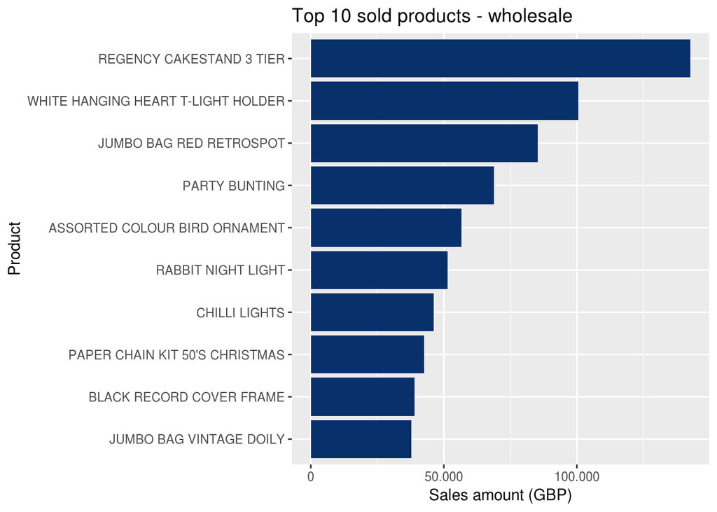

```r
top_10_products <- sales_transactions_tbl %>%
  mutate(CustomerGroup = ifelse(is.na(CustomerID), "Retail", "Wholesale")) %>%
  group_by(Description, CustomerGroup) %>%
  summarise(SalesAmount = sum(Quantity * UnitPrice, na.rm = TRUE)) %>%
  ungroup() %>%
  group_by(CustomerGroup) %>%
  filter(rank(desc(SalesAmount)) <= 10) %>%
  collect

top_10_products %>%
  filter(CustomerGroup == "Wholesale") %>%
  ggplot() +
  geom_bar(aes(x = reorder(factor(Description), SalesAmount), y = SalesAmount), stat = "identity", fill = "#08306b") +
  scale_y_continuous(labels = scales::format_format(big.mark = ".", decimal.mark = ",", scientific = FALSE)) +
  labs(x = "Product",
       y = "Sales amount (GBP)",
       title = "Top 10 sold products - wholesale") +
  coord_flip()
```

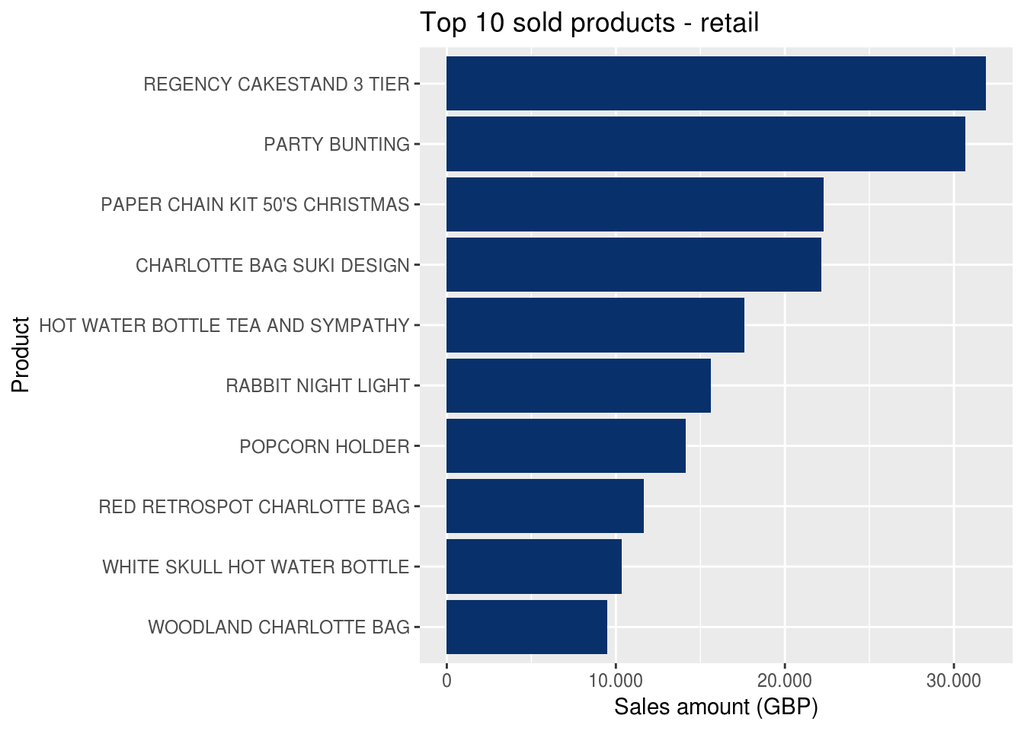

```r
top_10_products %>%
  filter(CustomerGroup == "Retail") %>%
  ggplot() +
  geom_bar(aes(x = reorder(factor(Description), SalesAmount), y = SalesAmount), stat = "identity", fill = "#08306b") +
  scale_y_continuous(labels = scales::format_format(big.mark = ".", decimal.mark = ",", scientific = FALSE)) +
  labs(x = "Product",
       y = "Sales amount (GBP)",
       title = "Top 10 sold products - retail") +
  coord_flip()
```

There are a couple of products that are common for top 10 sold products in retail and wholesale: “Regency cakestand 3 tier”, “Party bunting”, “Rabbit night light”, “Paper chain 50’s Christmas”. To continue the products versus revenue analysis, a hierarchy of products would be needed (normally it would be provided by the client).

### Which products are frequently bought together? The market basket analysis (frequent itemsets)

I’ll use the Spark’s MLlib machine learning library, which contains a parallelised implementation of the [frequent itemsets algorithm, FPgrowth](https://spark.apache.org/docs/2.3.1/ml-frequent-pattern-mining.html). I have to prepare the data first - fpgrowth expects one row per purchase, and all products in that purchase collapsed in a list.

```r
itemsets_tbl <- sales_transactions_tbl %>%
  select(InvoiceNo, Description) %>%
  distinct() %>%
  group_by(InvoiceNo) %>%
  summarise(items = collect_list(Description))

# let's look at how the prepared data looks like - one row, one invoice, and a list of its line items
head(itemsets_tbl)
```

| InvoiceNo <chr> | items <list> |  |  |  |
| --- | --- | --- | --- | --- |
| 536369 | <list [1]> |  |  |  |
| 536370 | <list [19]> |  |  |  |
| 536374 | <list [1]> |  |  |  |
| 536375 | <list [16]> |  |  |  |
| 536376 | <list [2]> |  |  |  |
| 536380 | <list [1]> |  |  |  |

6 rows

Let’s now run the FPgrowth. I’ve already tuned the hyperparameters to a sensible values for this case.

```r
# run the FPGrowth
fp_model <- ml_fpgrowth(itemsets_tbl, min_confidence = 0.5, min_support = 0.025)

# extract the derived frequent itemsets and reformat the data
freq_itemsets <- ml_freq_itemsets(fp_model) %>%
  collect %>%
  mutate(list_length = map_int(items, length)) %>%
  filter(list_length > 1) %>%
  arrange(desc(freq)) %>%
  mutate(itemset = map_chr(items, str_c, sep = "-", collapse = "-")) %>%
  select(-items, -list_length)

# display the itemsets
freq_itemsets
```

| freq <dbl> | itemset <chr> |  |  |
| --- | --- | --- | --- |
| 825 | JUMBO BAG PINK POLKADOT-JUMBO BAG RED RETROSPOT |  |  |
| 768 | GREEN REGENCY TEACUP AND SAUCER-ROSES REGENCY TEACUP AND SAUCER |  |  |
| 724 | JUMBO STORAGE BAG SUKI-JUMBO BAG RED RETROSPOT |  |  |
| 680 | JUMBO SHOPPER VINTAGE RED PAISLEY-JUMBO BAG RED RETROSPOT |  |  |
| 655 | LUNCH BAG SUKI DESIGN-LUNCH BAG RED RETROSPOT |  |  |
| 641 | LUNCH BAG BLACK SKULL.-LUNCH BAG RED RETROSPOT |  |  |
| 640 | ALARM CLOCK BAKELIKE GREEN-ALARM CLOCK BAKELIKE RED |  |  |
| 633 | PINK REGENCY TEACUP AND SAUCER-GREEN REGENCY TEACUP AND SAUCER |  |  |
| 606 | LUNCH BAG PINK POLKADOT-LUNCH BAG RED RETROSPOT |  |  |
| 599 | PINK REGENCY TEACUP AND SAUCER-ROSES REGENCY TEACUP AND SAUCER |  |  |

Next

12

Previous

1-10 of 17 rows

Here they are - pairs of items frequently purchased together. Column “freq” indicates in how many purchases does the product pair appear. It would be easier to see the itemsets arranged relative to frequency of appearance - here is one way to do it - a wordcloud:

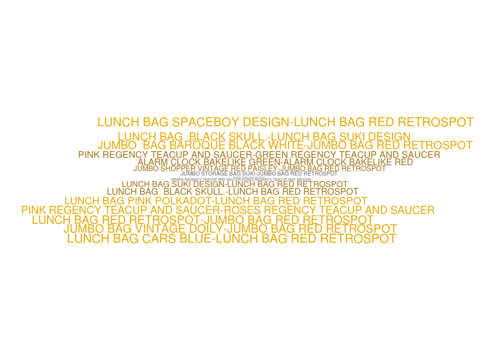

```r
library(wordcloud)

wordcloud(freq_itemsets$itemset, freq_itemsets$freq, max.words = 20, scale=c(0.1, 3.0),rot.per = 0,
               colors=brewer.pal(8, "Dark2"), random.order = FALSE, random.color = FALSE, fixed.asp = FALSE)
```

Notice that some products appear in more than one pair! That means it would be much more revealing to display the data in network form. It would also be helpful to see association directions between pair members - indicating the purchase of which product leads to purchase of another. Luckily, the FPgrowth algorithm provides us with just that - association rules! Let’s extract them and display them in network form. I’ll be using the D3 based network visualization.

```r
library(networkD3)

# extract association rules
assoc_rules <- ml_association_rules(fp_model) %>%
  collect %>%
  mutate(antecedent = map_chr(antecedent, str_c, sep = " + ", collapse = " + ")) %>%
  mutate(consequent = map_chr(consequent, str_c, sep = " + ", collapse = " + "))

# create a list of distinct antecedents
ante <- assoc_rules %>%
      distinct(antecedent) %>%
      transmute(name = antecedent)

# create a list of distinct consequents, combine them with distinct antecedents to create a list of network nodes
# add a unique id to every node
nodes <- assoc_rules %>%
  distinct(consequent) %>%
  transmute(name = consequent) %>%
  bind_rows(ante) %>%
  distinct() %>%
  mutate(group = "1") %>%
  mutate(row_id = seq(from = 0, length.out = length(name)), size = 20)

# extract directed link information from association rules, and add corresponding node IDs
links <- assoc_rules %>%
  left_join(nodes, by = c("antecedent" = "name")) %>%
  mutate(antecedent_row_id = row_id) %>%
  select(-row_id) %>%
  left_join(nodes, by = c("consequent" = "name")) %>%
  mutate(consequent_row_id = row_id) %>%
  select(-row_id,-group.x,-group.y)

# create the network visual using the nodes and links
forceNetwork(Links = as.data.frame(links), Nodes = as.data.frame(nodes), Source = "antecedent_row_id",
             Target = "consequent_row_id", Value = "confidence", NodeID = "name",
             Group = "group", opacity = 0.9, arrows = TRUE, linkWidth = JS("function(d) { return d.value * 4; }"),
             Nodesize = "size", fontSize = 15, fontFamily = "arial", linkDistance = 100, charge = -30, bounded = TRUE,
             opacityNoHover = 0.5)
```

[interactive chart not shown]

I can now clearly see that **items which are frequently bought together appear in clusters of variations of the same product**. This behavior is a signature of wholesale customers - when they order a product, they frequently order multiple variations of that product, to add variety to their gift shop offering.

It would be even more interesting to see how the itemsets change with seasons - since I already know from exploratory analysis that gifts are a seasonal business. That would be interesting for the client businesspeople too, so I’ll create a data driven interactive web application using the Shiny framework. You can see it here: [demo web app](https://renee-ahel.shinyapps.io/OnlineRetailDemo/).

### What would a wholesale customer buy next? The recommender engine

In the previous step I’ve detected products frequently purchased together over the whole customer base. To make an operational impact, I need to make next best product recomendations on individual customer level. I’ll use the Spark’s MLlib machine learning library, which contains an [ALS (alternating least squares)](https://spark.apache.org/docs/2.3.1/ml-collaborative-filtering.html) recommender engine. I’m focusing on wholesale customers, because I can identify them, unlike retail customers.

I have to prepare the data first. A recommender engine expects rating information for each customer-product pair - however, I only have the purchase information. Since this is often the case, it is possible to supply alternate information, such as purchase quantity - it is used as a measure of the strength of the relationship. I also have to generate a replacement ID for StockCode, as Spark ALS implementation currently accepts only integer values for product IDs, and some StockCodes contain letters. I also need to aggregate all purchases of the same product by the same customer, to enable ALS to construct a customer-product relationship matrix.

```r
ratings_tbl <- sales_transactions_tbl %>%
  filter(!is.na(CustomerID)) %>%
  select(CustomerID, StockCode, Description, Quantity) %>%
  group_by(CustomerID, StockCode, Description) %>%
  summarise(Quantity = sum(Quantity, na.rm = TRUE)) %>%
  ungroup() %>%
  mutate(CustomerID = as.integer(CustomerID),
         StockID = as.integer(rank(StockCode)))

# let's look at how the prepared data looks like - one row, one item, and a quantity transformed into 1-10 rating
head(ratings_tbl, 250)
```

| CustomerID <int> | StockCode <chr> | Description <chr> | Quantity <dbl> | StockID <int> |
| --- | --- | --- | --- | --- |
| 12583 | 10002 | INFLATABLE POLITICAL GLOBE | 48 | 1 |
| 16098 | 10002 | INFLATABLE POLITICAL GLOBE | 12 | 1 |
| 17967 | 10002 | INFLATABLE POLITICAL GLOBE | 1 | 1 |
| 13069 | 10002 | INFLATABLE POLITICAL GLOBE | 1 | 1 |
| 17677 | 10002 | INFLATABLE POLITICAL GLOBE | 24 | 1 |
| 15529 | 10002 | INFLATABLE POLITICAL GLOBE | 18 | 1 |
| 16795 | 10002 | INFLATABLE POLITICAL GLOBE | 8 | 1 |
| 12872 | 10002 | INFLATABLE POLITICAL GLOBE | 10 | 1 |
| 12682 | 10002 | INFLATABLE POLITICAL GLOBE | 24 | 1 |
| 14713 | 10002 | INFLATABLE POLITICAL GLOBE | 41 | 1 |

Next

123456

...

25

Previous

1-10 of 250 rows

```r
# How many ratings do I have?
ratings_tbl %>%
  summarise(row_count = n())
```

| row_count <dbl> |  |  |  |  |
| --- | --- | --- | --- | --- |
| 266325 |  |  |  |  |

1 row

```r
# create a stock ID and names table - to join it back to results
product_names_tbl <- ratings_tbl %>%
  select(StockID, StockCode, Description) %>%
  distinct()
```

There is a fair amount of ratings data - 266.325 rows. As I don’t have straight ratings to supply, I can’t test the model as a regressor, so I’ll supply the whole dataset for training.

```r
# train the ALS. I'll set the regularization parameter to 0.1, set implicit preference to true to indicate to ALS that ratings are actually derived from other information, and set the cold start to drop, to get only the results where the recommender returns a recommendation.
als_model <- ml_als(ratings_tbl, rating_col = "Quantity", user_col = "CustomerID",
  item_col = "StockID", reg_param = 0.1,
  implicit_prefs = TRUE, alpha = 1, nonnegative = FALSE,
  max_iter = 10, num_user_blocks = 10, num_item_blocks = 10,
  checkpoint_interval = 10, cold_start_strategy = "drop")
```

Let’s view the top 5 product recommendations for each customer.

```r
top_5_recommended_products <- ml_recommend(als_model, type = "items", 5) %>%
  inner_join(product_names_tbl, by = "StockID") %>%
  select(-recommendations) %>%
  arrange(CustomerID, desc(rating))

top_5_recommended_products %>%
  head(100)
```

| CustomerID <int> | StockID <int> | rating <dbl> | StockCode <chr> | Description <chr> |
| --- | --- | --- | --- | --- |
| 12347 | 157582 | 1.16040218 | 22915 | ASSORTED BOTTLE TOP MAGNETS |
| 12347 | 125590 | 1.13240862 | 22630 | DOLLY GIRL LUNCH BOX |
| 12347 | 125268 | 1.10198784 | 22629 | SPACEBOY LUNCH BOX |
| 12347 | 104899 | 1.09657085 | 22467 | GUMBALL COAT RACK |
| 12347 | 46765 | 1.08778095 | 21731 | RED TOADSTOOL LED NIGHT LIGHT |
| 12348 | 241881 | 1.12231314 | 84077 | WORLD WAR 2 GLIDERS ASSTD DESIGNS |
| 12348 | 49740 | 1.09995365 | 21790 | VINTAGE SNAP CARDS |
| 12348 | 25903 | 1.09991300 | 21212 | PACK OF 72 RETROSPOT CAKE CASES |
| 12348 | 82430 | 1.05286705 | 22197 | POPCORN HOLDER |
| 12348 | 63222 | 1.03290820 | 21985 | PACK OF 12 HEARTS DESIGN TISSUES |

Next

123456

...

10

Previous

1-10 of 100 rows

Let’s now compare for a couple of customers their purchase history and the recommendations.

Customer 12353 purchase history:

```r
ratings_tbl %>%
  filter(CustomerID == 12353) %>%
  arrange(CustomerID, desc(Quantity)) %>%
  select(CustomerID, StockCode, Description, Quantity)
```

| CustomerID <int> | StockCode <chr> | Description <chr> | Quantity <dbl> |  |
| --- | --- | --- | --- | --- |
| 12353 | 37446 | MINI CAKE STAND WITH HANGING CAKES | 8 |  |
| 12353 | 37450 | CERAMIC CAKE BOWL + HANGING CAKES | 6 |  |
| 12353 | 22890 | NOVELTY BISCUITS CAKE STAND 3 TIER | 4 |  |
| 12353 | 37449 | CERAMIC CAKE STAND + HANGING CAKES | 2 |  |

4 rows

Customer 12353 recommendations:

```r
top_5_recommended_products %>%
  filter(CustomerID == 12353) %>%
  arrange(CustomerID, desc(rating)) %>%
  select(CustomerID, StockCode, Description, rating)
```

| CustomerID <int> | StockCode <chr> | Description <chr> | rating <dbl> |  |
| --- | --- | --- | --- | --- |
| 12353 | 84568 | GIRLS ALPHABET IRON ON PATCHES | 0.10126924 |  |
| 12353 | 37448 | CERAMIC CAKE DESIGN SPOTTED MUG | 0.08732190 |  |
| 12353 | 22055 | MINI CAKE STAND HANGING STRAWBERY | 0.08556810 |  |
| 12353 | 22059 | CERAMIC STRAWBERRY DESIGN MUG | 0.08459042 |  |
| 12353 | 21232 | STRAWBERRY CERAMIC TRINKET BOX | 0.08299454 |  |

5 rows

Customer 12361 purchase history:

```r
ratings_tbl %>%
  filter(CustomerID == 12361) %>%
  arrange(CustomerID, desc(Quantity)) %>%
  select(CustomerID, StockCode, Description, Quantity)
```

| CustomerID <int> | StockCode <chr> | Description <chr> | Quantity <dbl> |  |
| --- | --- | --- | --- | --- |
| 12361 | 22631 | CIRCUS PARADE LUNCH BOX | 12 |  |
| 12361 | 22555 | PLASTERS IN TIN STRONGMAN | 12 |  |
| 12361 | 22629 | SPACEBOY LUNCH BOX | 12 |  |
| 12361 | 22630 | DOLLY GIRL LUNCH BOX | 12 |  |
| 12361 | 20726 | LUNCH BAG WOODLAND | 10 |  |
| 12361 | 22382 | LUNCH BAG SPACEBOY DESIGN | 10 |  |
| 12361 | 20725 | LUNCH BAG RED RETROSPOT | 10 |  |
| 12361 | 22326 | ROUND SNACK BOXES SET OF4 WOODLAND | 6 |  |
| 12361 | 22328 | ROUND SNACK BOXES SET OF 4 FRUITS | 6 |  |

9 rows

Customer 12361 recommendations:

```r
top_5_recommended_products %>%
  filter(CustomerID == 12361) %>%
  arrange(CustomerID, desc(rating)) %>%
  select(CustomerID, StockCode, Description, rating)
```

| CustomerID <int> | StockCode <chr> | Description <chr> | rating <dbl> |  |
| --- | --- | --- | --- | --- |
| 12361 | 20719 | WOODLAND CHARLOTTE BAG | 0.4590368 |  |
| 12361 | 20726 | LUNCH BAG WOODLAND | 0.4339479 |  |
| 12361 | 22382 | LUNCH BAG SPACEBOY DESIGN | 0.4321453 |  |
| 12361 | 22355 | CHARLOTTE BAG SUKI DESIGN | 0.4237228 |  |
| 12361 | 20724 | RED RETROSPOT CHARLOTTE BAG | 0.4224465 |  |

5 rows

Customer 12367 purchase history:

```r
ratings_tbl %>%
  filter(CustomerID == 12367) %>%
  arrange(CustomerID, desc(Quantity)) %>%
  select(CustomerID, StockCode, Description, Quantity)
```

| CustomerID <int> | StockCode <chr> | Description <chr> | Quantity <dbl> |  |
| --- | --- | --- | --- | --- |
| 12367 | 16237 | SLEEPING CAT ERASERS | 60 |  |
| 12367 | 22045 | SPACEBOY GIFT WRAP | 25 |  |
| 12367 | 22708 | WRAP DOLLY GIRL | 25 |  |
| 12367 | 22631 | CIRCUS PARADE LUNCH BOX | 12 |  |
| 12367 | 85227 | SET OF 6 3D KIT CARDS FOR KIDS | 12 |  |
| 12367 | 22630 | DOLLY GIRL LUNCH BOX | 12 |  |
| 12367 | 22629 | SPACEBOY LUNCH BOX | 12 |  |
| 12367 | 21576 | LETS GO SHOPPING COTTON TOTE BAG | 6 |  |
| 12367 | 21579 | LOLITA DESIGN COTTON TOTE BAG | 6 |  |
| 12367 | 21770 | OPEN CLOSED METAL SIGN | 2 |  |

1-10 of 10 rows

Customer 12367 recommendations:

```r
top_5_recommended_products %>%
  filter(CustomerID == 12367) %>%
  arrange(CustomerID, desc(rating)) %>%
  select(CustomerID, StockCode, Description, rating)
```

| CustomerID <int> | StockCode <chr> | Description <chr> | rating <dbl> |  |
| --- | --- | --- | --- | --- |
| 12367 | 22027 | TEA PARTY BIRTHDAY CARD | 0.5381333 |  |
| 12367 | 22029 | SPACEBOY BIRTHDAY CARD | 0.5164015 |  |
| 12367 | 22045 | SPACEBOY GIFT WRAP | 0.4970031 |  |
| 12367 | 22037 | ROBOT BIRTHDAY CARD | 0.4885558 |  |
| 12367 | 21915 | RED HARMONICA IN BOX | 0.4725820 |  |

5 rows

Customer 12401 purchase history:

```r
ratings_tbl %>%
  filter(CustomerID == 12401) %>%
  arrange(CustomerID, desc(Quantity)) %>%
  select(CustomerID, StockCode, Description, Quantity)
```

| CustomerID <int> | StockCode <chr> | Description <chr> | Quantity <dbl> |  |
| --- | --- | --- | --- | --- |
| 12401 | 84279B | CHERRY BLOSSOM DECORATIVE FLASK | 4 |  |
| 12401 | 15056BL | EDWARDIAN PARASOL BLACK | 3 |  |
| 12401 | 22423 | REGENCY CAKESTAND 3 TIER | 2 |  |
| 12401 | 21843 | RED RETROSPOT CAKE STAND | 1 |  |

4 rows

Customer 12401 recommendations:

```r
top_5_recommended_products %>%
  filter(CustomerID == 12401) %>%
  arrange(CustomerID, desc(rating)) %>%
  select(CustomerID, StockCode, Description, rating)
```

| CustomerID <int> | StockCode <chr> | Description <chr> | rating <dbl> |  |
| --- | --- | --- | --- | --- |
| 12401 | 22699 | ROSES REGENCY TEACUP AND SAUCER | 0.05345554 |  |
| 12401 | 22697 | GREEN REGENCY TEACUP AND SAUCER | 0.05325226 |  |
| 12401 | 79000 | MOROCCAN TEA GLASS | 0.05231123 |  |
| 12401 | 22423 | REGENCY CAKESTAND 3 TIER | 0.05228526 |  |
| 12401 | 22698 | PINK REGENCY TEACUP AND SAUCER | 0.05164512 |  |

5 rows

Customer 12441 purchase history:

```r
ratings_tbl %>%
  filter(CustomerID == 12441) %>%
  arrange(CustomerID, desc(Quantity)) %>%
  select(CustomerID, StockCode, Description, Quantity)
```

| CustomerID <int> | StockCode <chr> | Description <chr> | Quantity <dbl> |  |
| --- | --- | --- | --- | --- |
| 12441 | 22051 | BLUE SCANDINAVIAN PAISLEY WRAP | 25 |  |
| 12441 | 22710 | WRAP I LOVE LONDON | 25 |  |
| 12441 | 22052 | VINTAGE CARAVAN GIFT WRAP | 25 |  |
| 12441 | 85049A | TRADITIONAL CHRISTMAS RIBBONS | 12 |  |
| 12441 | 22742 | MAKE YOUR OWN PLAYTIME CARD KIT | 6 |  |
| 12441 | 22086 | PAPER CHAIN KIT 50'S CHRISTMAS | 6 |  |
| 12441 | 22744 | MAKE YOUR OWN MONSOON CARD KIT | 6 |  |
| 12441 | 22910 | PAPER CHAIN KIT VINTAGE CHRISTMAS | 6 |  |
| 12441 | 47566B | TEA TIME PARTY BUNTING | 5 |  |
| 12441 | 37495 | FAIRY CAKE BIRTHDAY CANDLE SET | 4 |  |

1-10 of 10 rows

Customer 12441 recommendations:

```r
top_5_recommended_products %>%
  filter(CustomerID == 12441) %>%
  arrange(CustomerID, desc(rating)) %>%
  select(CustomerID, StockCode, Description, rating)
```

| CustomerID <int> | StockCode <chr> | Description <chr> | rating <dbl> |  |
| --- | --- | --- | --- | --- |
| 12441 | 16169E | WRAP 50'S CHRISTMAS | 0.4296483 |  |
| 12441 | 21499 | BLUE POLKADOT WRAP | 0.4106539 |  |
| 12441 | 21497 | FANCY FONTS BIRTHDAY WRAP | 0.3990867 |  |
| 12441 | 21498 | RED RETROSPOT WRAP | 0.3977441 |  |
| 12441 | 23232 | WRAP VINTAGE LEAF DESIGN | 0.3965289 |  |

5 rows

From the examples I can see that the recommender is making sensible recommendations. In a real world project, the next step would be to make the recommender operational - by exposing an API for the webshop application to use, or to deliver data via batch jobs to an interface database table, or any other way of integration suitable for the webshop system. In this case I’ll demonstrate how the recommender performs by displaying its output in a webapp I’ve already created to display other useful information for the buisnesspeople. You can see it here: [demo web app](https://renee-ahel.shinyapps.io/OnlineRetailDemo/).

Finished! Disconnect from Spark.

```r
spark_disconnect(sc)
```